**Programmazione di Applicazioni Data Intensive**  
Laurea in Ingegneria e Scienze Informatiche  
DISI - Università di Bologna, Cesena

Luca Marini, Simone Mattioli

# **Classificazione: Determinare la posizione di un calciatore in base alle sue caratteristiche**

FIFA 19 è un videogioco di calcio sviluppato da EA Sports, pubblicato il 28 settembre 2018 per PlayStation 3 (con supporto PlayStation Move), PlayStation 4, Xbox 360, Xbox One (con Kinect), Microsoft Windows e Nintendo Switch. [fifa19_wikipedia](https://it.wikipedia.org/wiki/FIFA_19)

**Definizione del problema**

Il progetto ha lo scopo di classificare il ruolo di un giocatore in base alle sue caratteristiche fisiche e tecniche.

# **Librerie**

```python
import numpy as np
import pandas as pd
import matplotlib.pyplot as plt
from matplotlib import cm
import matplotlib.patches as mpatches

import sklearn
import pickle
from scipy.stats import norm
import seaborn as sns
import os.path
from imblearn.over_sampling import SMOTE
from sklearn.model_selection import GridSearchCV, StratifiedKFold
from sklearn.metrics import f1_score
from sklearn.preprocessing import StandardScaler
from sklearn.pipeline import Pipeline
from sklearn.model_selection import train_test_split
from sklearn.linear_model import LogisticRegression, Perceptron
from sklearn.svm import SVC
from sklearn.neighbors import KNeighborsClassifier
from sklearn.neural_network import MLPClassifier
from xgboost import XGBClassifier
from sklearn.metrics import classification_report, confusion_matrix, accuracy_score
from sklearn.dummy import DummyClassifier
from google.colab import files

pd.set_option('max_rows', 99999)
```

### Caricamento dei dati

```python
if not os.path.exists("fifa.csv"):
    from urllib.request import urlretrieve
    urlretrieve("https://raw.githubusercontent.com/amanthedorkknight/fifa18-all-player-statistics/master/2019/data.csv", "fifa.csv")
```

```python
fifa = pd.read_csv("fifa.csv")
```

# **Esplorazione dei dati**

Il dataset comprende:

- 18207 diverse istanze, ognuna rappresentante un giocatore
- ad ogni giocatore è associato un insieme di 89 colonne contengono informazioni anagrafiche, statistiche, caratteristiche fisiche e tecniche e il ruolo

```python
len(fifa)
```

```
18207
```

```python
len(fifa.columns)
```

```
89
```

```python
fifa.head(3)
```

|  | Unnamed: 0 | ID | Name | Age | Photo | Nationality | Flag | Overall | Potential | Club | Club Logo | Value | Wage | Special | Preferred Foot | International Reputation | Weak Foot | Skill Moves | Work Rate | Body Type | Real Face | Position | Jersey Number | Joined | Loaned From | Contract Valid Until | Height | Weight | LS | … |
| --- | --- | --- | --- | --- | --- | --- | --- | --- | --- | --- | --- | --- | --- | --- | --- | --- | --- | --- | --- | --- | --- | --- | --- | --- | --- | --- | --- | --- | --- | --- |
| 0 | 0 | 158023 | L. Messi | 31 | https://cdn.sofifa.org/players/4/19/158023.png | Argentina | https://cdn.sofifa.org/flags/52.png | 94 | 94 | FC Barcelona | https://cdn.sofifa.org/teams/2/light/241.png | €110.5M | €565K | 2202 | Left | 5.0 | 4.0 | 4.0 | Medium/ Medium | Messi | Yes | RF | 10.0 | Jul 1, 2004 | NaN | 2021 | 5'7 | 159lbs | 88+2 | … |
| 1 | 1 | 20801 | Cristiano Ronaldo | 33 | https://cdn.sofifa.org/players/4/19/20801.png | Portugal | https://cdn.sofifa.org/flags/38.png | 94 | 94 | Juventus | https://cdn.sofifa.org/teams/2/light/45.png | €77M | €405K | 2228 | Right | 5.0 | 4.0 | 5.0 | High/ Low | C. Ronaldo | Yes | ST | 7.0 | Jul 10, 2018 | NaN | 2022 | 6'2 | 183lbs | 91+3 | … |
| 2 | 2 | 190871 | Neymar Jr | 26 | https://cdn.sofifa.org/players/4/19/190871.png | Brazil | https://cdn.sofifa.org/flags/54.png | 92 | 93 | Paris Saint-Germain | https://cdn.sofifa.org/teams/2/light/73.png | €118.5M | €290K | 2143 | Right | 5.0 | 5.0 | 5.0 | High/ Medium | Neymar | Yes | LW | 10.0 | Aug 3, 2017 | NaN | 2022 | 5'9 | 150lbs | 84+3 | … |

3 rows × 89 columns

```python
fifa.tail(3)
```

|  | Unnamed: 0 | ID | Name | Age | Photo | Nationality | Flag | Overall | Potential | Club | Club Logo | Value | Wage | Special | Preferred Foot | International Reputation | Weak Foot | Skill Moves | Work Rate | Body Type | Real Face | Position | Jersey Number | Joined | Loaned From | Contract Valid Until | Height | Weight | LS | … |
| --- | --- | --- | --- | --- | --- | --- | --- | --- | --- | --- | --- | --- | --- | --- | --- | --- | --- | --- | --- | --- | --- | --- | --- | --- | --- | --- | --- | --- | --- | --- |
| 18204 | 18204 | 241638 | B. Worman | 16 | https://cdn.sofifa.org/players/4/19/241638.png | England | https://cdn.sofifa.org/flags/14.png | 47 | 67 | Cambridge United | https://cdn.sofifa.org/teams/2/light/1944.png | €60K | €1K | 1189 | Right | 1.0 | 3.0 | 2.0 | Medium/ Medium | Normal | No | ST | 33.0 | Jul 1, 2017 | NaN | 2021 | 5'8 | 148lbs | 45+2 | … |
| 18205 | 18205 | 246268 | D. Walker-Rice | 17 | https://cdn.sofifa.org/players/4/19/246268.png | England | https://cdn.sofifa.org/flags/14.png | 47 | 66 | Tranmere Rovers | https://cdn.sofifa.org/teams/2/light/15048.png | €60K | €1K | 1228 | Right | 1.0 | 3.0 | 2.0 | Medium/ Medium | Lean | No | RW | 34.0 | Apr 24, 2018 | NaN | 2019 | 5'10 | 154lbs | 47+2 | … |
| 18206 | 18206 | 246269 | G. Nugent | 16 | https://cdn.sofifa.org/players/4/19/246269.png | England | https://cdn.sofifa.org/flags/14.png | 46 | 66 | Tranmere Rovers | https://cdn.sofifa.org/teams/2/light/15048.png | €60K | €1K | 1321 | Right | 1.0 | 3.0 | 2.0 | Medium/ Medium | Lean | No | CM | 33.0 | Oct 30, 2018 | NaN | 2019 | 5'10 | 176lbs | 43+2 | … |

3 rows × 89 columns

Di seguito sono riportate le dimensioni in memoria, il numero di istanze non nulle e il tipo delle feature che compongono i dati raccolti nel dataset

```python
fifa.info(memory_usage="deep")
```

```
<class 'pandas.core.frame.DataFrame'>
RangeIndex: 18207 entries, 0 to 18206
Data columns (total 89 columns):
 #   Column                    Non-Null Count  Dtype
---  ------                    --------------  -----
 0   Unnamed: 0                18207 non-null  int64
 1   ID                        18207 non-null  int64
 2   Name                      18207 non-null  object
 3   Age                       18207 non-null  int64
 4   Photo                     18207 non-null  object
 5   Nationality               18207 non-null  object
 6   Flag                      18207 non-null  object
 7   Overall                   18207 non-null  int64
 8   Potential                 18207 non-null  int64
 9   Club                      17966 non-null  object
```

[output cut: 81 more lines]

# **Significato delle feature**

Di seguito sono riportate le informazioni sul [Data Set](https://www.kaggle.com/karangadiya/fifa19) utilizzato

**Statistiche generali:**

- `Name`: nome del giocatore
- `Age`: età giocatore
- `Nationality`: nazionalità giocatore
- `Overall`: potenziale del giocatore calcolato sulla base delle sue statistiche chiave (es. valocità, passaggio, tiro, fisico, dribbling, difesa per i giocatori non portieri, altrimenti viene aggiunta la statistica "riflessi") e la sua reputazione internazionale.
- `Potential`: potenziale Overall di miglioramento
- `Club`: club di appartenenza
- `Value`: valore monetario del giocatore
- `Wage`: stipendio del giocatore
- `Preferred Foot`: piede preferito
- `International Reputation`: fama del giocatore a livello internazionale su scala da 0 a 5
- `Weak Foot`: abilità di utilizzo del piede debole su una scala da 0 a 5
- `Skill Moves`: abilità di utilizzo di finte per il dribbling
- `Work Rate`: profensione che il giocatore ha nel lavorare per la squadra in fase offensiva/difensiva
- `Position`: posizione ricoperta dal giocatore
- `Jersey Number`: numero di maglia del giocatore
- `Height`: altezza giocatore
- `Weight`: peso giocatore
- `Photo`: url contenente l'immagine del giocatore
- `Contract Valid Until`: anno di termine del contratto del giocatore
- `Flag`: url contenente l'immagine della nazione del giocatore
- `Joined`: data in cui il giocatore si è unito al club
- `Club Logo`: url contenente l'immagine del logo del club
- `Body Type`: tipo di corpo
- `Real Face`: specifica se il viso virtuale del calciatore è ottenuto da una scansione di quello del calciatore reale
- `Loaned From`: club precedente di appartenenza
- `ID, Unnamed: 0`: identificatori
- `valutazione da 0 a 100 di quanto un giocatore è adatto a un ruolo specifico`: "LS", "ST", "RS", "LW", "LF", "CF", "RF", "RW", "LAM", "CAM", "RAM", "LM", "LCM", "CM", "RCM", "RM", "LWB", "LDM", "CDM", "RDM", "RWB", "LB", "LCB", "CB", "RCB", "RB", "Special"

**Statistiche tecniche:**

Le statistiche tecniche sono espresse da un numero che va da 0 a 99 e maggiore è il numero, più un calciatore ha padronanza di quella statistica.

- `Crossing`: abilità nel cross
- `Finishing`: abiltà nel tiro in porta
- `HeadingAccuracy`: abilità nel colpo di testa
- `ShortPassing`: anilità nel passaggio corto
- `Volleys`: abilità nel tiro al volo
- `Dribbling`: abilità nel dribbling
- `Curve`: abilità nel tiro a giro
- `FKAccuracy`: abilità sui calci di punizione
- `LongPassing`: abilità sui passaggi lunghi
- `BallControl`: controllo di palla
- `Acceleration`: accelerazione
- `SprintSpeed`: velocità di scatto
- `Agility`: agilità
- `Reactions`: abilità nel reagire prontamente alle situazioni
- `Balance`: equilibrio
- `ShotPower`: potenza di tiro
- `Jumping`: abilità nel saltare
- `Stamina`: resitenza
- `Strength`: forza fisica
- `LongShots`: abilità nel tiro dalla distanza
- `Aggression`: aggressività
- `Interception`: abilità nell'intercettare il pallone
- `Positioning`: abilità nel posizionarsi in campo
- `Vision`: abilità nella visione di gioco
- `Penalties`: abilità del giocatore sui calci di rigore
- `Composure`: freddezza del giocatore sotto pressione
- `Marking`: abilità nel marcare gli avversari
- `StandingTackle`: abilità nell'effettuare contrasti da in piedi
- `SlidingTackle`: abilità nell'effettuare contrasti in scivolata
- `GKDiving`: abilità del portiere nel tuffo
- `GKHandling`: abilità del portiere nel trattenere il pallone
- `GKKicking`: abilità del portiere nel calciare il pallone
- `GkPositioning`: abilità del portiere nel posizionamento in porta
- `GKReflexes`: riflessi del portiere

# **Variabile da predire**

**Definizione delle classi**

La variabile da predire è `Position`, ovvero la posizione del giocatore. Questa colonna contiene 27 diversi valori. Per semplificare il problema si è deciso di diminuire il numero da 27 a 8 ruoli più generali:

- `Goalkeeper`: Portiere
- `Central Back`: Difensore centrale
- `Left Back`: Terzino sinistro
- `Right Back`: Terzino destro
- `Central Midfielder`: Centrocampista centrale
- `Central Defensive Midfielder`: Mediano
- `Forward`: Attaccante
- `Wing`: Ala

```python
# Lista delle 27 posizioni
fifa['Position'].unique()
```

```
array(['RF', 'ST', 'LW', 'GK', 'RCM', 'LF', 'RS', 'RCB', 'LCM', 'CB',
       'LDM', 'CAM', 'CDM', 'LS', 'LCB', 'RM', 'LAM', 'LM', 'LB', 'RDM',
       'RW', 'CM', 'RB', 'RAM', 'CF', 'RWB', 'LWB', nan], dtype=object)
```

```python
#portieri
fifa['Position'] = fifa['Position'].replace(dict.fromkeys(['GK'], 'Goalkeeper'))

#difensori
fifa['Position'] = fifa['Position'].replace(dict.fromkeys(['CB', 'RCB', 'LCB'], 'Central Back'))
fifa['Position'] = fifa['Position'].replace(dict.fromkeys(['LB', 'LWB'], 'Left Back'))
fifa['Position'] = fifa['Position'].replace(dict.fromkeys(['RB', 'RWB'], 'Right Back'))

#centrocampisti
fifa['Position'] = fifa['Position'].replace(dict.fromkeys(['RCM','LCM','CM', 'CAM'], 'Central Midfilder'))
fifa['Position'] = fifa['Position'].replace(dict.fromkeys(['RDM','LDM','CDM'], 'Central Defensive Midfilder'))

#attaccanti
fifa['Position'] = fifa['Position'].replace(dict.fromkeys(['ST', 'CF','LF','RF'], 'Forward'))
fifa['Position'] = fifa['Position'].replace(dict.fromkeys(['RS', 'RW','RM' ,'LW', 'RAM','LAM', 'LS','LM'],'Wing'))

fifa['Position'].unique()
```

```
array(['Forward', 'Wing', 'Goalkeeper', 'Central Midfilder',
       'Central Back', 'Central Defensive Midfilder', 'Left Back',
       'Right Back', nan], dtype=object)
```

# **Feature scarsamente utili**

Si è deciso di eliminare alcune colonne che non portano alcuna informazione utile al raggiungimento dell'obiettivo preposto:

- `Photo`: url contenente l'immagine del giocatore
- `Name`: nome del giocatore
- `Club`: club al quale appartiene il giocatore
- `Nationality`: nazionalità del giocatore
- `Contract Valid Until`: anno di termine del contratto del giocatore
- `Flag`: url contenente l'immagine della nazione del giocatore
- `Joined`: data in cui il giocatore si è unito al club
- `Club Logo`: url contenente l'immagine del logo del club
- `Body Type`: tipo di corpo
- `Real Face`: specifica se il viso virtuale del calciatore è ottenuto da una scansione di quello del calciatore reale
- `Loaned From`: club precedente di appartenenza
- `ID, Unnamed: 0`: identificatori
- `Special`

Queste ultime feature sono state eliminate, poichè avrebbero reso banale la classificazione del ruolo.

```python
fifa = fifa.drop(columns=["Name", "Nationality", "Club","Photo",
                          "Contract Valid Until", "Flag", "Club Logo",
                          "Body Type", "Real Face", "Loaned From",
                          "Release Clause", "Joined", "ID", "Unnamed: 0",
                          "Special"])
```

Ora il dataset è composto da 74 colonne

```python
len(fifa.columns)
```

```
74
```

```python
fifa.head(3)
```

|  | Age | Overall | Potential | Value | Wage | Preferred Foot | International Reputation | Weak Foot | Skill Moves | Work Rate | Position | Jersey Number | Height | Weight | LS | ST | RS | LW | LF | CF | RF | RW | LAM | CAM | RAM | LM | LCM | CM | RCM | … |
| --- | --- | --- | --- | --- | --- | --- | --- | --- | --- | --- | --- | --- | --- | --- | --- | --- | --- | --- | --- | --- | --- | --- | --- | --- | --- | --- | --- | --- | --- | --- |
| 0 | 31 | 94 | 94 | €110.5M | €565K | Left | 5.0 | 4.0 | 4.0 | Medium/ Medium | Forward | 10.0 | 5'7 | 159lbs | 88+2 | 88+2 | 88+2 | 92+2 | 93+2 | 93+2 | 93+2 | 92+2 | 93+2 | 93+2 | 93+2 | 91+2 | 84+2 | 84+2 | 84+2 | … |
| 1 | 33 | 94 | 94 | €77M | €405K | Right | 5.0 | 4.0 | 5.0 | High/ Low | Forward | 7.0 | 6'2 | 183lbs | 91+3 | 91+3 | 91+3 | 89+3 | 90+3 | 90+3 | 90+3 | 89+3 | 88+3 | 88+3 | 88+3 | 88+3 | 81+3 | 81+3 | 81+3 | … |
| 2 | 26 | 92 | 93 | €118.5M | €290K | Right | 5.0 | 5.0 | 5.0 | High/ Medium | Wing | 10.0 | 5'9 | 150lbs | 84+3 | 84+3 | 84+3 | 89+3 | 89+3 | 89+3 | 89+3 | 89+3 | 89+3 | 89+3 | 89+3 | 88+3 | 81+3 | 81+3 | 81+3 | … |

```python
fifa.describe()
```

|  | Age | Overall | Potential | International Reputation | Weak Foot | Skill Moves | Jersey Number | Crossing | Finishing | HeadingAccuracy | ShortPassing | Volleys | Dribbling | Curve | FKAccuracy | LongPassing | BallControl | Acceleration | SprintSpeed | Agility | Reactions | Balance | ShotPower | Jumping | Stamina | Strength | LongShots | Aggression | Interceptions | … |
| --- | --- | --- | --- | --- | --- | --- | --- | --- | --- | --- | --- | --- | --- | --- | --- | --- | --- | --- | --- | --- | --- | --- | --- | --- | --- | --- | --- | --- | --- | --- |
| count | 18207.000000 | 18207.000000 | 18207.000000 | 18159.000000 | 18159.000000 | 18159.000000 | 18147.000000 | 18159.000000 | 18159.000000 | 18159.000000 | 18159.000000 | 18159.000000 | 18159.000000 | 18159.000000 | 18159.000000 | 18159.000000 | 18159.000000 | 18159.000000 | 18159.000000 | 18159.000000 | 18159.000000 | 18159.000000 | 18159.000000 | 18159.000000 | 18159.000000 | 18159.000000 | 18159.000000 | 18159.000000 | 18159.000000 | … |
| mean | 25.122206 | 66.238699 | 71.307299 | 1.113222 | 2.947299 | 2.361308 | 19.546096 | 49.734181 | 45.550911 | 52.298144 | 58.686712 | 42.909026 | 55.371001 | 47.170824 | 42.863153 | 52.711933 | 58.369459 | 64.614076 | 64.726967 | 63.503607 | 61.836610 | 63.966573 | 55.460047 | 65.089432 | 63.219946 | 65.311967 | 47.109973 | 55.868991 | 46.698276 | … |
| std | 4.669943 | 6.908930 | 6.136496 | 0.394031 | 0.660456 | 0.756164 | 15.947765 | 18.364524 | 19.525820 | 17.379909 | 14.699495 | 17.694408 | 18.910371 | 18.395264 | 17.478763 | 15.327870 | 16.686595 | 14.927780 | 14.649953 | 14.766049 | 9.010464 | 14.136166 | 17.237958 | 11.820044 | 15.894741 | 12.557000 | 19.260524 | 17.367967 | 20.696909 | … |
| min | 16.000000 | 46.000000 | 48.000000 | 1.000000 | 1.000000 | 1.000000 | 1.000000 | 5.000000 | 2.000000 | 4.000000 | 7.000000 | 4.000000 | 4.000000 | 6.000000 | 3.000000 | 9.000000 | 5.000000 | 12.000000 | 12.000000 | 14.000000 | 21.000000 | 16.000000 | 2.000000 | 15.000000 | 12.000000 | 17.000000 | 3.000000 | 11.000000 | 3.000000 | … |
| 25% | 21.000000 | 62.000000 | 67.000000 | 1.000000 | 3.000000 | 2.000000 | 8.000000 | 38.000000 | 30.000000 | 44.000000 | 54.000000 | 30.000000 | 49.000000 | 34.000000 | 31.000000 | 43.000000 | 54.000000 | 57.000000 | 57.000000 | 55.000000 | 56.000000 | 56.000000 | 45.000000 | 58.000000 | 56.000000 | 58.000000 | 33.000000 | 44.000000 | 26.000000 | … |
| 50% | 25.000000 | 66.000000 | 71.000000 | 1.000000 | 3.000000 | 2.000000 | 17.000000 | 54.000000 | 49.000000 | 56.000000 | 62.000000 | 44.000000 | 61.000000 | 48.000000 | 41.000000 | 56.000000 | 63.000000 | 67.000000 | 67.000000 | 66.000000 | 62.000000 | 66.000000 | 59.000000 | 66.000000 | 66.000000 | 67.000000 | 51.000000 | 59.000000 | 52.000000 | … |
| 75% | 28.000000 | 71.000000 | 75.000000 | 1.000000 | 3.000000 | 3.000000 | 26.000000 | 64.000000 | 62.000000 | 64.000000 | 68.000000 | 57.000000 | 68.000000 | 62.000000 | 57.000000 | 64.000000 | 69.000000 | 75.000000 | 75.000000 | 74.000000 | 68.000000 | 74.000000 | 68.000000 | 73.000000 | 74.000000 | 74.000000 | 62.000000 | 69.000000 | 64.000000 | … |
| max | 45.000000 | 94.000000 | 95.000000 | 5.000000 | 5.000000 | 5.000000 | 99.000000 | 93.000000 | 95.000000 | 94.000000 | 93.000000 | 90.000000 | 97.000000 | 94.000000 | 94.000000 | 93.000000 | 96.000000 | 97.000000 | 96.000000 | 96.000000 | 96.000000 | 96.000000 | 95.000000 | 95.000000 | 96.000000 | 97.000000 | 94.000000 | 95.000000 | 92.000000 | … |

## **Gestione dei valori mancanti**

Elenco delle colonne del Dataframe che contengono dei valori nulli:

```python
nullseries = fifa.isnull().sum()
print(nullseries[nullseries > 0])
```

```
Preferred Foot                48
International Reputation      48
Weak Foot                     48
Skill Moves                   48
Work Rate                     48
Position                      60
Jersey Number                 60
Height                        48
Weight                        48
LS                          2085
ST                          2085
RS                          2085
LW                          2085
LF                          2085
CF                          2085
RF                          2085
RW                          2085
LAM                         2085
CAM                         2085
RAM                         2085
LM                          2085
LCM                         2085
CM                          2085
RCM                         2085
RM                          2085
LWB                         2085
LDM                         2085
CDM                         2085
RDM                         2085
RWB                         2085
LB                          2085
LCB                         2085
CB                          2085
RCB                         2085
RB                          2085
Crossing                      48
Finishing                     48
HeadingAccuracy               48
ShortPassing                  48
Volleys                       48
```

[output cut: 15 more lines]

```
Aggression                    48
Interceptions                 48
Positioning                   48
Vision                        48
Penalties                     48
Composure                     48
Marking                       48
StandingTackle                48
SlidingTackle                 48
GKDiving                      48
GKHandling                    48
GKKicking                     48
GKPositioning                 48
GKReflexes                    48
dtype: int64
```

```python
fifa = fifa.dropna(subset=['Position'])
nullseries = fifa.isnull().sum()
print(nullseries[nullseries > 0])
```

```
LS     2025
ST     2025
RS     2025
LW     2025
LF     2025
CF     2025
RF     2025
RW     2025
LAM    2025
CAM    2025
RAM    2025
LM     2025
LCM    2025
CM     2025
RCM    2025
RM     2025
LWB    2025
LDM    2025
CDM    2025
RDM    2025
RWB    2025
LB     2025
LCB    2025
CB     2025
RCB    2025
RB     2025
dtype: int64
```

Rimangono 2025 istanze che contengono valori nulli nelle colonne di valutazioni da 0 a 100 di quanto un giocatore è adatto a un ruolo specifico. Si scopre che tutte queste tuple sono i portieri.

```python
for role in fifa.loc[:, 'LS':'RB'].columns:
  zero_players = fifa[fifa[role].isnull()]
zero_players['Position'].unique()
```

```
array(['Goalkeeper'], dtype=object)
```

```python
fifa.loc[fifa['Position'] == 'Goalkeeper'].head(3)
```

|  | Age | Overall | Potential | Value | Wage | Preferred Foot | International Reputation | Weak Foot | Skill Moves | Work Rate | Position | Jersey Number | Height | Weight | LS | ST | RS | LW | LF | CF | RF | RW | LAM | CAM | RAM | LM | LCM | CM | RCM | … |
| --- | --- | --- | --- | --- | --- | --- | --- | --- | --- | --- | --- | --- | --- | --- | --- | --- | --- | --- | --- | --- | --- | --- | --- | --- | --- | --- | --- | --- | --- | --- |
| 3 | 27 | 91 | 93 | €72M | €260K | Right | 4.0 | 3.0 | 1.0 | Medium/ Medium | Goalkeeper | 1.0 | 6'4 | 168lbs | NaN | NaN | NaN | NaN | NaN | NaN | NaN | NaN | NaN | NaN | NaN | NaN | NaN | NaN | NaN | … |
| 9 | 25 | 90 | 93 | €68M | €94K | Right | 3.0 | 3.0 | 1.0 | Medium/ Medium | Goalkeeper | 1.0 | 6'2 | 192lbs | NaN | NaN | NaN | NaN | NaN | NaN | NaN | NaN | NaN | NaN | NaN | NaN | NaN | NaN | NaN | … |
| 18 | 26 | 89 | 92 | €58M | €240K | Right | 3.0 | 4.0 | 1.0 | Medium/ Medium | Goalkeeper | 22.0 | 6'2 | 187lbs | NaN | NaN | NaN | NaN | NaN | NaN | NaN | NaN | NaN | NaN | NaN | NaN | NaN | NaN | NaN | … |

Quindi si sostituiscono tutti questi valori assenti con degli zeri.

```python
fifa = fifa.fillna(0)
```

```python
nullseries = fifa.isnull().sum()
print(nullseries[nullseries > 0])
```

```
Series([], dtype: int64)
```

```python
fifa.head()
```

|  | Age | Overall | Potential | Value | Wage | Preferred Foot | International Reputation | Weak Foot | Skill Moves | Work Rate | Position | Jersey Number | Height | Weight | LS | ST | RS | LW | LF | CF | RF | RW | LAM | CAM | RAM | LM | LCM | CM | RCM | … |
| --- | --- | --- | --- | --- | --- | --- | --- | --- | --- | --- | --- | --- | --- | --- | --- | --- | --- | --- | --- | --- | --- | --- | --- | --- | --- | --- | --- | --- | --- | --- |
| 0 | 31 | 94 | 94 | €110.5M | €565K | Left | 5.0 | 4.0 | 4.0 | Medium/ Medium | Forward | 10.0 | 5'7 | 159lbs | 88+2 | 88+2 | 88+2 | 92+2 | 93+2 | 93+2 | 93+2 | 92+2 | 93+2 | 93+2 | 93+2 | 91+2 | 84+2 | 84+2 | 84+2 | … |
| 1 | 33 | 94 | 94 | €77M | €405K | Right | 5.0 | 4.0 | 5.0 | High/ Low | Forward | 7.0 | 6'2 | 183lbs | 91+3 | 91+3 | 91+3 | 89+3 | 90+3 | 90+3 | 90+3 | 89+3 | 88+3 | 88+3 | 88+3 | 88+3 | 81+3 | 81+3 | 81+3 | … |
| 2 | 26 | 92 | 93 | €118.5M | €290K | Right | 5.0 | 5.0 | 5.0 | High/ Medium | Wing | 10.0 | 5'9 | 150lbs | 84+3 | 84+3 | 84+3 | 89+3 | 89+3 | 89+3 | 89+3 | 89+3 | 89+3 | 89+3 | 89+3 | 88+3 | 81+3 | 81+3 | 81+3 | … |
| 3 | 27 | 91 | 93 | €72M | €260K | Right | 4.0 | 3.0 | 1.0 | Medium/ Medium | Goalkeeper | 1.0 | 6'4 | 168lbs | 0 | 0 | 0 | 0 | 0 | 0 | 0 | 0 | 0 | 0 | 0 | 0 | 0 | 0 | 0 | … |
| 4 | 27 | 91 | 92 | €102M | €355K | Right | 4.0 | 5.0 | 4.0 | High/ High | Central Midfilder | 7.0 | 5'11 | 154lbs | 82+3 | 82+3 | 82+3 | 87+3 | 87+3 | 87+3 | 87+3 | 87+3 | 88+3 | 88+3 | 88+3 | 88+3 | 87+3 | 87+3 | 87+3 | … |

Come si può notare, ora non esiste più alcun dato nullo.

## **Conversione di dati**

In seguito si è passati alla conversione dei valori contenuti nelle seguenti colonne:

- `Weight`: il peso dei giocatori è stato convertito da una stringa espressa in libbre ad un float che rappresenta i chilogrammi
- `Height`: è stata modificata l'unità di misura dell'altezza, da foot (piedi) a cm (centimetri)
- `Value`: il valore di un giocatore è espresso da una stringa, tramite un numero e una lettera che indica quanti zeri devono essere aggiunti al numero stesso (ad es. K = * 1000), quindi lo si è trasformato in un unico numero
- `Wage`: stesso discorso di Value, ma applicato allo stipendio del calciatore
- `WorkRate`: è stata divisa in due colonne separando il lavoro in fase offensiva da quello in fase difensiva, ed è stato convertito il valore da stringa (Low, Medium, High) a intero (1, 2, 3)
- `Preferred Feet`: la colonna di stringhe è stata convertita in una colonna di booleani: True -> Right, False -> Left, e per chiarezza la feature è stata rinominata in `Prefers Right Foot`
- `Valutazioni da 0 a 100 di quanto un giocatore è adatto a un ruolo specifico`: queste colonne, rappresentate da una stringa formata da 2 numeri separati da un '+', sono state trasformate in un intero

```python
# funzione che converte il peso dei giocatori da libbre a chilogrammi

def from_lbs_to_kgs(value):
  out = value.replace('lbs', '')
  return float(out) * 0.45

fifa['Weight'] = fifa['Weight'].apply(lambda x : from_lbs_to_kgs(x))
fifa['Weight'].head()
```

```
0    71.55
1    82.35
2    67.50
3    75.60
4    69.30
Name: Weight, dtype: float64
```

```python
# funzione che converte l'altezza dei giocatori in centimetri partendo dalla
# stessa espressa in piedi

def from_foot_to_cm(value):
  h = value.split("'")
  h_ft = int(h[0])
  h_inch = int(h[1])
  h_inch += h_ft * 12
  h_cm = round(h_inch * 2.54, 1)
  return h_cm

fifa['Height'] = fifa['Height'].apply(lambda x : from_foot_to_cm(x))
fifa['Height'].head()
```

```
0    170.2
1    188.0
2    175.3
3    193.0
4    180.3
Name: Height, dtype: float64
```

```python
# funzione con la quale si ottengono i valori monetari come numeri (in euro)
# partendo da una stringa

def get_accurate_money_number(Value):
    out = Value.replace('€', '')
    if 'M' in out:
        out = float(out.replace('M', ''))*1000000
    elif 'K' in Value:
        out = float(out.replace('K', ''))*1000
    return float(out)

fifa['Value'] = fifa['Value'].apply(lambda x: get_accurate_money_number(x))
fifa['Wage'] = fifa['Wage'].apply(lambda x: get_accurate_money_number(x))

fifa['Wage'].head()
fifa['Value'].head()
```

```
0    110500000.0
1     77000000.0
2    118500000.0
3     72000000.0
4    102000000.0
Name: Value, dtype: float64
```

```python
# funzione che associa a ciascuna classe di rate un intero positivo
def from_string_to_int_rate(value):
  switcher = {
      'Low':1,
      'Medium':2,
      'High':3
  }
  return switcher.get(value,0)

WorkRate_separation = fifa['Work Rate'].str.split('/ ',1,expand = True)
WorkRate_separation[0] = WorkRate_separation[0].apply(lambda x : from_string_to_int_rate(x))
WorkRate_separation[1] = WorkRate_separation[1].apply(lambda x : from_string_to_int_rate(x))
fifa['WROffensive'] = WorkRate_separation[0]
fifa['WRDefensive'] = WorkRate_separation[1]
fifa.drop(columns = ['Work Rate'], inplace = True)
```

```python
#binariziamo la colonna 'Preferred Foot'
fifa = fifa.rename(columns={'Preferred Foot':'Prefers Right Foot'})
foot = {'Right':True,'Left':False}
fifa['Prefers Right Foot'] = fifa['Prefers Right Foot'].map(foot)
```

```python
for role in fifa.loc[:, 'LS':'RB'].columns:
    value = fifa[role].str.split('+',1,expand = True)
    fifa[role] = value[0]

fifa = fifa.fillna(0)

for role in fifa.loc[:, 'LS':'RB'].columns:
    fifa[role] = fifa[role].astype(int)
```

```python
fifa = fifa[[ 'Overall', 'Potential', 'LS', 'ST', 'RS', 'LW', 'LF', 'CF', 'RF',
             'RW', 'LAM', 'CAM', 'RAM', 'LM', 'LCM', 'CM', 'RCM', 'RM', 'LWB',
             'LDM', 'CDM', 'RDM', 'RWB', 'LB', 'LCB', 'CB', 'RCB', 'RB','Value',
             'Wage','Age', 'WROffensive','WRDefensive',
             'International Reputation', 'Weak Foot', 'Skill Moves', 'Height',
             'Weight','Prefers Right Foot', 'Position', 'Crossing', 'Finishing',
             'HeadingAccuracy', 'ShortPassing', 'Volleys', 'Dribbling', 'Curve',
             'FKAccuracy', 'LongPassing', 'BallControl', 'Acceleration',
             'SprintSpeed', 'Agility', 'Reactions', 'Balance', 'ShotPower',
             'Jumping', 'Stamina', 'Strength', 'LongShots', 'Aggression',
             'Interceptions', 'Positioning', 'Vision', 'Penalties', 'Composure',
             'Marking', 'StandingTackle', 'SlidingTackle', 'GKDiving',
             'GKHandling', 'GKKicking', 'GKPositioning', 'GKReflexes',
             'Jersey Number']]
```

```python
fifa.head(2)
```

|  | Overall | Potential | LS | ST | RS | LW | LF | CF | RF | RW | LAM | CAM | RAM | LM | LCM | CM | RCM | RM | LWB | LDM | CDM | RDM | RWB | LB | LCB | CB | RCB | RB | Value | … |
| --- | --- | --- | --- | --- | --- | --- | --- | --- | --- | --- | --- | --- | --- | --- | --- | --- | --- | --- | --- | --- | --- | --- | --- | --- | --- | --- | --- | --- | --- | --- |
| 0 | 94 | 94 | 88 | 88 | 88 | 92 | 93 | 93 | 93 | 92 | 93 | 93 | 93 | 91 | 84 | 84 | 84 | 91 | 64 | 61 | 61 | 61 | 64 | 59 | 47 | 47 | 47 | 59 | 110500000.0 | … |
| 1 | 94 | 94 | 91 | 91 | 91 | 89 | 90 | 90 | 90 | 89 | 88 | 88 | 88 | 88 | 81 | 81 | 81 | 88 | 65 | 61 | 61 | 61 | 65 | 61 | 53 | 53 | 53 | 61 | 77000000.0 | … |

# **Analisi dei dati**

Di seguito viene visualizzato il numero di giocatori per ogni posizione ricoperta

```python
fifa["Position"].value_counts()
```

```
Wing                           3422
Central Midfilder              3138
Central Back                   3088
Forward                        2257
Goalkeeper                     2025
Central Defensive Midfilder    1439
Left Back                      1400
Right Back                     1378
Name: Position, dtype: int64
```

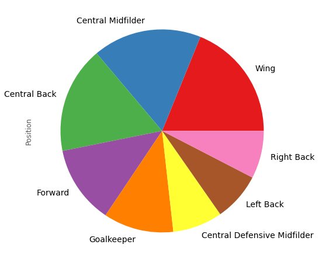

```python
plt.style.use('ggplot')
cs=cm.Set1(np.arange(8)/8.)
plt.figure(figsize=(8, 8))
fifa["Position"].value_counts().plot.pie(fontsize=14, colors=cs)
```

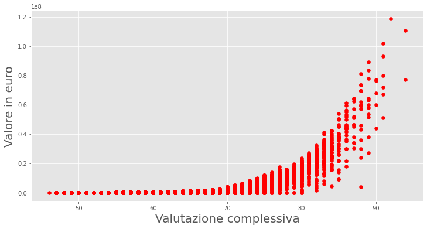

```python
plt.figure(figsize=(12, 6))
plt.scatter(fifa['Overall'], fifa['Value'], c = 'red');
plt.xlabel('Valutazione complessiva', fontsize = 20)
plt.ylabel('Valore in euro', fontsize = 20)
```

Questo grafico evidenzia la correlazione, che ha un andamento simile a una funzione esponenziale, tra la valutazione complessiva di un giocatore e il suo valore espresso in euro.

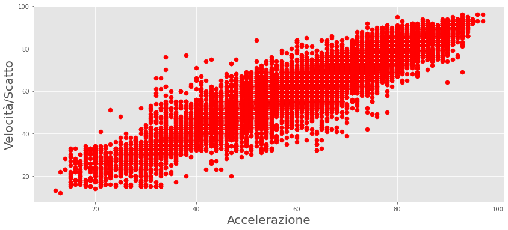

```python
plt.figure(figsize=(14, 6))
plt.scatter(fifa['Acceleration'], fifa['SprintSpeed'], c = 'red', s = 50);
plt.xlabel('Accelerazione', fontsize = 20)
plt.ylabel('Velocità/Scatto', fontsize = 20)
```

Il grafico riportato sopra mostra come al crescere dell'accelerazione aumenti anche la velocità di un giocatore, e quindi si ha una proporzionalità diretta tra le due variabili.

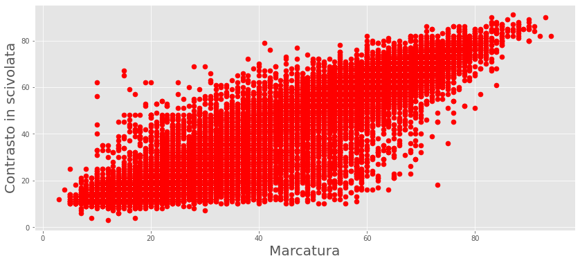

```python
labels = fifa["Position"].unique()
plt.figure(figsize=(14, 6))
plt.scatter(fifa['Marking'], fifa['SlidingTackle'], c='red', s = 50);
plt.xlabel('Marcatura', fontsize = 20)
plt.ylabel('Contrasto in scivolata', fontsize = 20)
```

In ambito difensivo, in generale, l'abilità nel marcare è direttamente proporzionale all'abilità che un calciatore ha nel contrasto in scivolata.

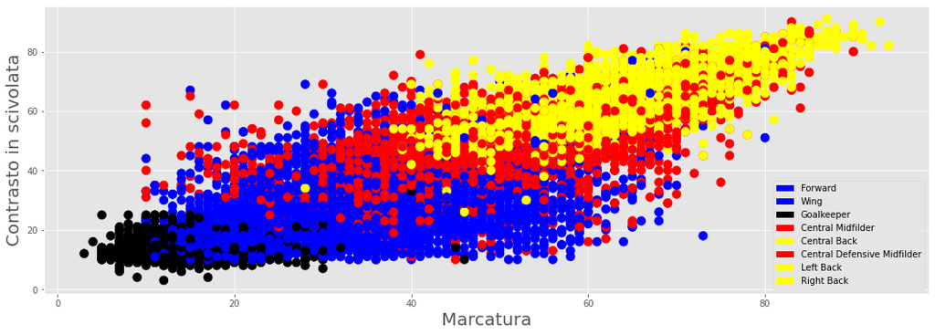

```python
defending_skills_color_map = {"Wing": "blue", "Forward": "blue",
                              "Goalkeeper":"black",
                              "Central Midfilder":"red",
                              "Central Back":"yellow",
                              "Central Defensive Midfilder":"red",
                              "Left Back":"yellow", "Right Back":"yellow"}
defending_skills_colors = fifa["Position"].map(defending_skills_color_map)
plt.figure(figsize=(18, 6))
plt.scatter(fifa['Marking'], fifa['SlidingTackle'], c = defending_skills_colors,
            s = 100);
plt.xlabel('Marcatura', fontsize = 20)
plt.ylabel('Contrasto in scivolata', fontsize = 20)

classes = fifa['Position'].unique()
class_colours = defending_skills_color_map.values()
recs = []

for i in range(0,len(class_colours)):
    recs.append(mpatches.Rectangle((0,0),1,1,fc=list(class_colours)[i]))
plt.legend(recs,classes,loc=4)
```

quindi i giocatori più bravi nel difendere sono appunto i difensori, seguiti dai centrocampisti e dagli attaccanti, e infine ci sono i portieri.

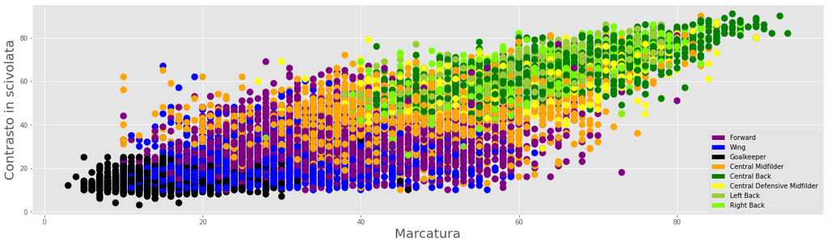

```python
defending_skills_color_map = {"Wing": "purple", "Forward": "blue",
                              "Goalkeeper":"black",
                              "Central Midfilder":"orange",
                              "Central Back":"green",
                              "Central Defensive Midfilder":"yellow",
                              "Left Back":"yellowgreen",
                              "Right Back":"lawngreen"}
defending_skills_colors = fifa["Position"].map(defending_skills_color_map)
plt.figure(figsize=(22, 6))
plt.scatter(fifa['Marking'], fifa['SlidingTackle'], c = defending_skills_colors,
            s = 100);
plt.xlabel('Marcatura', fontsize = 20)
plt.ylabel('Contrasto in scivolata', fontsize = 20)

classes = fifa['Position'].unique()
class_colours = defending_skills_color_map.values()
recs = []

for i in range(0,len(class_colours)):
    recs.append(mpatches.Rectangle((0,0),1,1,fc=list(class_colours)[i]))
plt.legend(recs,classes,loc=4)
```

Suddividendo il grafico precedente nelle 8 posizioni si nota che:

- i ruoli più difensivi sono Central Back, Right Back, e Left Back, ovvero l'insieme dei ruoli difensivi
- seguiti poi dalle posizioni di centrocampo, ovvero Central Defensive Midfilder, Central Midfilder
- infine, l'abilità difensiva decresce seguendo il seguente ordine: Wing, Forward e Goalkeeper

In seguito è stata eseguita un'analisi sui dati per ottenere e visualizzare i valori medi di tutte statistiche per ognuno dei 8 ruoli presi in considerazione.

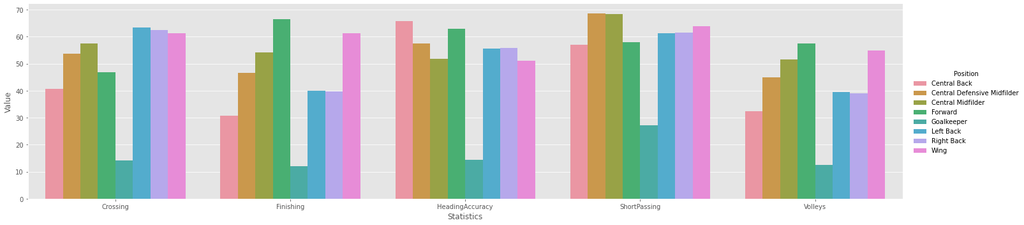

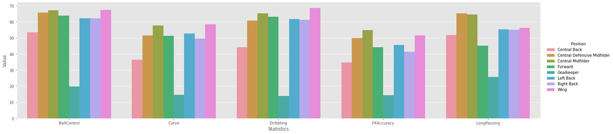

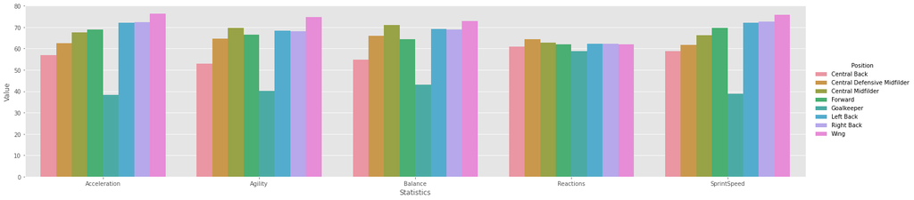

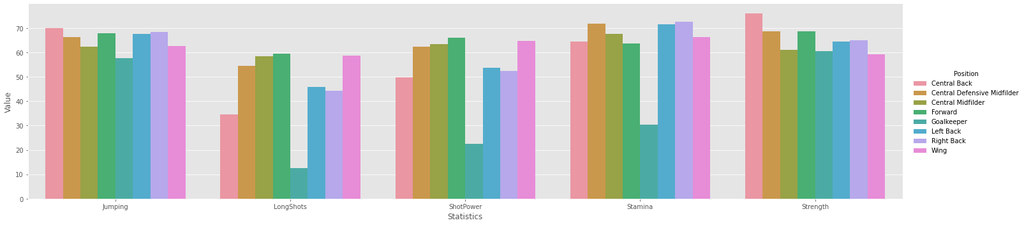

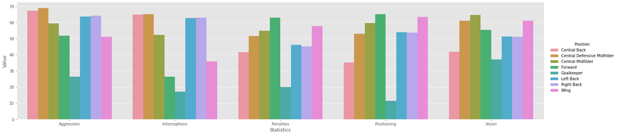

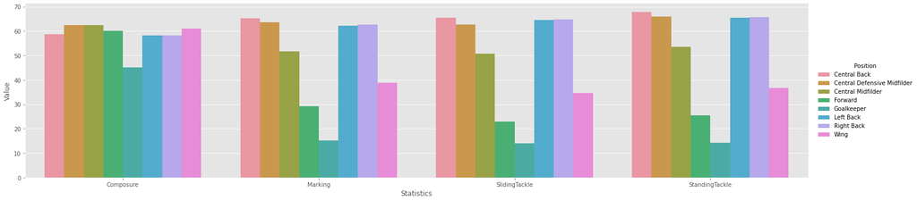

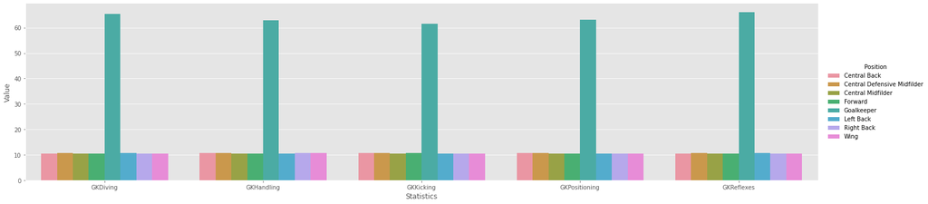

```python
technical_statistics = fifa.loc[:,'Position':"GKReflexes"]

technical_1 = technical_statistics.loc[:,'Crossing':'Volleys']
technical_2 = technical_statistics.loc[:,'Dribbling':'BallControl']
technical_3 = technical_statistics.loc[:,'Acceleration':'Balance']
technical_4 = technical_statistics.loc[:,'ShotPower':'LongShots']
technical_5 = technical_statistics.loc[:,'Aggression':'Penalties']
technical_6 = technical_statistics.loc[:,'Composure':'SlidingTackle']
technical_7 = technical_statistics.loc[:,'GKDiving':'GKReflexes']


technical_1['Position'] = technical_statistics['Position']
technical_2['Position'] = technical_statistics['Position']
technical_3['Position'] = technical_statistics['Position']
technical_4['Position'] = technical_statistics['Position']
technical_5['Position'] = technical_statistics['Position']
technical_6['Position'] = technical_statistics['Position']
technical_7['Position'] = technical_statistics['Position']


x1 = technical_1.melt(id_vars='Position',var_name='Statistics',value_name='Value').groupby(['Position','Statistics'], as_index = False).mean()
x2 = technical_2.melt(id_vars='Position',var_name='Statistics',value_name='Value').groupby(['Position','Statistics'], as_index = False).mean()
x3 = technical_3.melt(id_vars='Position',var_name='Statistics',value_name='Value').groupby(['Position','Statistics'], as_index = False).mean()
x4 = technical_4.melt(id_vars='Position',var_name='Statistics',value_name='Value').groupby(['Position','Statistics'], as_index = False).mean()
x5 = technical_5.melt(id_vars='Position',var_name='Statistics',value_name='Value').groupby(['Position','Statistics'], as_index = False).mean()
x6 = technical_6.melt(id_vars='Position',var_name='Statistics',value_name='Value').groupby(['Position','Statistics'], as_index = False).mean()
x7 = technical_7.melt(id_vars='Position',var_name='Statistics',value_name='Value').groupby(['Position','Statistics'], as_index = False).mean()


sns.catplot(x="Statistics", y="Value", hue="Position", kind="bar", data=x1, height=5,aspect=4 );
sns.catplot(x="Statistics", y="Value", hue="Position", kind="bar", data=x2, height=5,aspect=4 );
sns.catplot(x="Statistics", y="Value", hue="Position", kind="bar", data=x3, height=5,aspect=4 );
sns.catplot(x="Statistics", y="Value", hue="Position", kind="bar", data=x4, height=5,aspect=4 );
sns.catplot(x="Statistics", y="Value", hue="Position", kind="bar", data=x5, height=5,aspect=4 );
sns.catplot(x="Statistics", y="Value", hue="Position", kind="bar", data=x6, height=5,aspect=4 );
sns.catplot(x="Statistics", y="Value", hue="Position", kind="bar", data=x7, height=5,aspect=4 );
```

I grafici sovrastanti riportano il valore medio di ogni singola statistica, raggruppando per posizione di gioco, in particolare si può osservare che:

- i calciatori che hanno una maggiore abilità nel tiro in porta (`Finishing`) sono gli attaccanti, seguiti dalle ali e dai centrocampisti centrali
- come visto precedentemente, i 4 ruoli più difensivi (`Central Back`, `Left Back`, `Right back` e `Central Defensive Midfielder`) sono quelli più predisposti ad avere una media maggiore nelle statistiche di difesa come la scivolata, l'abilità nell'effettuare contrasti da in piedi, la marcatura el'abilità nell'intercettare il pallone
- per quanto riguarda le abilità legate ai portieri, come il tuffo, la parata, il posizionamento in porta, ovviamente i portieri stessi hanno una media nettamente superiore agli altri

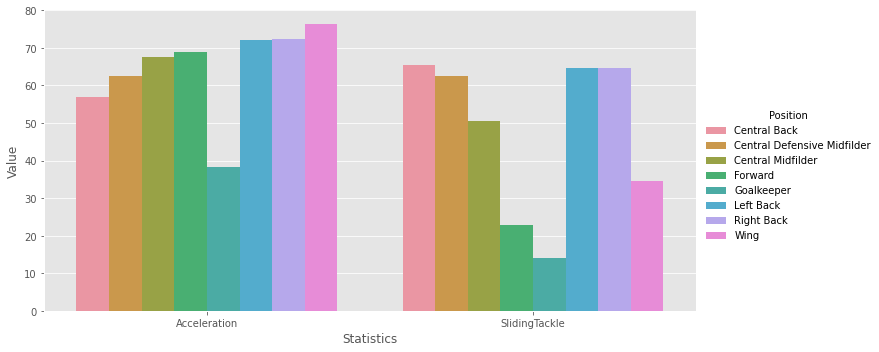

```python
technical_statistics = fifa.loc[:,['Position','Acceleration','SlidingTackle']]
df =technical_statistics.melt(id_vars='Position',var_name='Statistics',
                              value_name='Value').groupby(['Position','Statistics'], as_index = False).mean()
sns.catplot(x="Statistics", y="Value", hue="Position", kind="bar", data=df, height=5,aspect=2 );
```

Si può notare che i giocatori con una buona accelerazione e scarsa abilità nell'eseguire una scivolata sono gli attaccanti (`Forward`).

```python
fifa.head(5)
```

|  | Overall | Potential | LS | ST | RS | LW | LF | CF | RF | RW | LAM | CAM | RAM | LM | LCM | CM | RCM | RM | LWB | LDM | CDM | RDM | RWB | LB | LCB | CB | RCB | RB | Value | … |
| --- | --- | --- | --- | --- | --- | --- | --- | --- | --- | --- | --- | --- | --- | --- | --- | --- | --- | --- | --- | --- | --- | --- | --- | --- | --- | --- | --- | --- | --- | --- |
| 0 | 94 | 94 | 88 | 88 | 88 | 92 | 93 | 93 | 93 | 92 | 93 | 93 | 93 | 91 | 84 | 84 | 84 | 91 | 64 | 61 | 61 | 61 | 64 | 59 | 47 | 47 | 47 | 59 | 110500000.0 | … |
| 1 | 94 | 94 | 91 | 91 | 91 | 89 | 90 | 90 | 90 | 89 | 88 | 88 | 88 | 88 | 81 | 81 | 81 | 88 | 65 | 61 | 61 | 61 | 65 | 61 | 53 | 53 | 53 | 61 | 77000000.0 | … |
| 2 | 92 | 93 | 84 | 84 | 84 | 89 | 89 | 89 | 89 | 89 | 89 | 89 | 89 | 88 | 81 | 81 | 81 | 88 | 65 | 60 | 60 | 60 | 65 | 60 | 47 | 47 | 47 | 60 | 118500000.0 | … |
| 3 | 91 | 93 | 0 | 0 | 0 | 0 | 0 | 0 | 0 | 0 | 0 | 0 | 0 | 0 | 0 | 0 | 0 | 0 | 0 | 0 | 0 | 0 | 0 | 0 | 0 | 0 | 0 | 0 | 72000000.0 | … |
| 4 | 91 | 92 | 82 | 82 | 82 | 87 | 87 | 87 | 87 | 87 | 88 | 88 | 88 | 88 | 87 | 87 | 87 | 88 | 77 | 77 | 77 | 77 | 77 | 73 | 66 | 66 | 66 | 73 | 102000000.0 | … |

# **Standardizzazione dei dati**

Prima di procedere, dato che nel nostro dataset troviamo dei valori con scale diverse, si standardizzano i valori in modo tale da averne una serie in una distribuzione normale standard con media uguale a 0 e deviazione standard uguale a 1.

```python
X = fifa.drop(columns=["Position"])
y = fifa["Position"]

X_train, X_val, y_train, y_val = \
    train_test_split(X, y, test_size=1/4, random_state=42)

scaler = StandardScaler()

Xs_train = scaler.fit_transform(X_train)
Xs_val = scaler.fit_transform(X_val)
```

# **Scelta del modello**

Iniziamo lo studio dei modelli di classificazione partendo dal più semplice: il Perceptron.

**Appunto sulla GridSearch : nelle grid search sono mostrati solo gli iperparametri che hanno ottenuto i risultati migliori, per permettere un'esecuzione complessiva più rapida. Gli iperparametri 'commentati' sono stati testati in notebook separati.**

## **Perceptron**

A seguito di diversi testi ci siamo accorti che per questo modello la cross fold validation con 5 fold dava il risultato migliore quindi in questa dimostrazione verrà utilizzzato 5 come numero di fold.

```python
skf = StratifiedKFold(5, shuffle=True)

perceptron = Pipeline([
              ("perc", Perceptron(random_state=42))
])
```

```python
grid_perc = {
    'perc__penalty' : ['l1','l2',None],
    'perc__class_weight' : ['balanced', None],
    'perc__alpha' : np.logspace(-7, -1, 7)
}

gs_perc = GridSearchCV(perceptron, scoring='accuracy', param_grid = grid_perc, cv=skf)
gs_perc.fit(Xs_train, y_train);
```

```python
gs_perc.best_params_
```

```
{'perc__alpha': 1e-05, 'perc__class_weight': None, 'perc__penalty': 'l1'}
```

```python
pd.DataFrame(gs_perc.cv_results_).sort_values("rank_test_score").head(5)
```

|  | mean_fit_time | std_fit_time | mean_score_time | std_score_time | param_perc__alpha | param_perc__class_weight | param_perc__penalty | params | split0_test_score | split1_test_score | split2_test_score | split3_test_score | split4_test_score | mean_test_score | std_test_score | rank_test_score |
| --- | --- | --- | --- | --- | --- | --- | --- | --- | --- | --- | --- | --- | --- | --- | --- | --- |
| 15 | 1.161738 | 0.213466 | 0.006005 | 0.000084 | 1e-05 | None | l1 | {'perc__alpha': 1e-05, 'perc__class_weight': N... | 0.751653 | 0.736958 | 0.725202 | 0.701690 | 0.680382 | 0.719177 | 0.025369 | 1 |
| 12 | 1.108043 | 0.089812 | 0.006148 | 0.000376 | 1e-05 | balanced | l1 | {'perc__alpha': 1e-05, 'perc__class_weight': '... | 0.695077 | 0.705364 | 0.739162 | 0.714916 | 0.709405 | 0.712785 | 0.014699 | 2 |
| 10 | 0.286656 | 0.023051 | 0.005976 | 0.000116 | 1e-06 | None | l2 | {'perc__alpha': 1e-06, 'perc__class_weight': N... | 0.707201 | 0.695812 | 0.732550 | 0.718589 | 0.700588 | 0.710948 | 0.013233 | 3 |
| 1 | 0.277853 | 0.023242 | 0.005959 | 0.000104 | 1e-07 | balanced | l2 | {'perc__alpha': 1e-07, 'perc__class_weight': '... | 0.701323 | 0.711976 | 0.722263 | 0.718222 | 0.696547 | 0.710066 | 0.009779 | 4 |
| 7 | 0.271572 | 0.027225 | 0.006008 | 0.000114 | 1e-06 | balanced | l2 | {'perc__alpha': 1e-06, 'perc__class_weight': '... | 0.672667 | 0.708303 | 0.715650 | 0.713446 | 0.727774 | 0.707568 | 0.018584 | 5 |

```python
gs_perc.score(Xs_val,y_val)
```

```
0.7333039453383293
```

```python
with open("model_perceptron.bin", "wb") as f:
    pickle.dump(gs_perc.best_estimator_, f)
```

```python
# files.download('model_perceptron.bin')
```

## **KNeighborsClassifier**

```python
model_KN = Pipeline([
    ("kn", KNeighborsClassifier())
])

grid_KN = {
    'kn__n_neighbors' : [5,10,20,30,40],
    'kn__weights' : ['distance', 'uniform'],
    'kn__p' : [1,2]
}

gs_KN = GridSearchCV(model_KN, scoring='accuracy', param_grid = grid_KN, cv=skf)
gs_KN.fit(Xs_train, y_train);
```

```python
gs_KN.best_params_
```

```
{'kn__n_neighbors': 30, 'kn__p': 1, 'kn__weights': 'distance'}
```

```python
pd.DataFrame(gs_KN.cv_results_).sort_values("rank_test_score").head(5)
```

|  | mean_fit_time | std_fit_time | mean_score_time | std_score_time | param_kn__n_neighbors | param_kn__p | param_kn__weights | params | split0_test_score | split1_test_score | split2_test_score | split3_test_score | split4_test_score | mean_test_score | std_test_score | rank_test_score |
| --- | --- | --- | --- | --- | --- | --- | --- | --- | --- | --- | --- | --- | --- | --- | --- | --- |
| 12 | 0.117752 | 0.002465 | 5.877149 | 0.341864 | 30 | 1 | distance | {'kn__n_neighbors': 30, 'kn__p': 1, 'kn__weigh... | 0.764879 | 0.757899 | 0.754960 | 0.766716 | 0.738428 | 0.756576 | 0.010055 | 1 |
| 8 | 0.118047 | 0.001598 | 6.198368 | 0.083531 | 20 | 1 | distance | {'kn__n_neighbors': 20, 'kn__p': 1, 'kn__weigh... | 0.765614 | 0.756429 | 0.752388 | 0.761940 | 0.739162 | 0.755107 | 0.009170 | 2 |
| 13 | 0.117035 | 0.002807 | 5.889364 | 0.388930 | 30 | 1 | uniform | {'kn__n_neighbors': 30, 'kn__p': 1, 'kn__weigh... | 0.765246 | 0.756796 | 0.750918 | 0.767450 | 0.733652 | 0.754813 | 0.012128 | 3 |
| 16 | 0.120491 | 0.002319 | 6.309567 | 0.239269 | 40 | 1 | distance | {'kn__n_neighbors': 40, 'kn__p': 1, 'kn__weigh... | 0.765981 | 0.757899 | 0.748347 | 0.762675 | 0.737325 | 0.754445 | 0.010421 | 4 |
| 9 | 0.118837 | 0.002271 | 5.950401 | 0.218542 | 20 | 1 | uniform | {'kn__n_neighbors': 20, 'kn__p': 1, 'kn__weigh... | 0.763409 | 0.754960 | 0.746877 | 0.759735 | 0.739162 | 0.752829 | 0.008791 | 5 |

```python
gs_KN.score(Xs_val,y_val)
```

```
0.7674674895305268
```

```python
with open("model_KN.bin", "wb") as f:
    pickle.dump(gs_KN.best_estimator_, f)
```

```python
# files.download('model_KN.bin')
```

## **Regressione Logistica**

```python
skfLR = StratifiedKFold(3, shuffle=True)
model_LR = Pipeline([
    ("logreg", LogisticRegression())
])
grid_LR = {
    "logreg__max_iter": [3000],
    "logreg__n_jobs": [-1],
    "logreg__solver": ["saga"],
    "logreg__penalty": ["l2", "l1"],# [elasticnet, None]
    "logreg__C": [ 1, 10], #[0.01, 0.1]
    "logreg__multi_class": ["ovr", "multinomial"]
}
gs_LR = GridSearchCV(model_LR, grid_LR, cv=skfLR)
gs_LR.fit(Xs_train, y_train);
```

```python
gs_LR.best_params_
```

```
{'logreg__C': 10,
 'logreg__max_iter': 3000,
 'logreg__multi_class': 'multinomial',
 'logreg__n_jobs': -1,
 'logreg__penalty': 'l1',
 'logreg__solver': 'saga'}
```

```python
pd.DataFrame(gs_LR.cv_results_).sort_values("rank_test_score").head(5)
```

|  | mean_fit_time | std_fit_time | mean_score_time | std_score_time | param_logreg__C | param_logreg__max_iter | param_logreg__multi_class | param_logreg__n_jobs | param_logreg__penalty | param_logreg__solver | params | split0_test_score | split1_test_score | split2_test_score | mean_test_score | std_test_score | rank_test_score |
| --- | --- | --- | --- | --- | --- | --- | --- | --- | --- | --- | --- | --- | --- | --- | --- | --- | --- |
| 7 | 145.526828 | 11.780593 | 0.011648 | 0.000174 | 10 | 3000 | multinomial | -1 | l1 | saga | {'logreg__C': 10, 'logreg__max_iter': 3000, 'l... | 0.788847 | 0.792153 | 0.782628 | 0.787876 | 0.003949 | 1 |
| 3 | 89.654598 | 12.428570 | 0.011331 | 0.000145 | 1 | 3000 | multinomial | -1 | l1 | saga | {'logreg__C': 1, 'logreg__max_iter': 3000, 'lo... | 0.787525 | 0.792153 | 0.782848 | 0.787509 | 0.003799 | 2 |
| 6 | 82.458862 | 8.124619 | 0.011569 | 0.000166 | 10 | 3000 | multinomial | -1 | l2 | saga | {'logreg__C': 10, 'logreg__max_iter': 3000, 'l... | 0.788186 | 0.791933 | 0.782187 | 0.787435 | 0.004014 | 3 |
| 2 | 23.125242 | 0.966411 | 0.011247 | 0.000076 | 1 | 3000 | multinomial | -1 | l2 | saga | {'logreg__C': 1, 'logreg__max_iter': 3000, 'lo... | 0.788627 | 0.789729 | 0.783510 | 0.787288 | 0.002710 | 4 |
| 4 | 100.999913 | 14.221498 | 0.011280 | 0.000222 | 10 | 3000 | ovr | -1 | l2 | saga | {'logreg__C': 10, 'logreg__max_iter': 3000, 'l... | 0.787745 | 0.786864 | 0.779982 | 0.784864 | 0.003470 | 5 |

```python
gs_LR.score(Xs_val, y_val)
```

```
0.7974432444346484
```

```python
with open("model_LR.bin", "wb") as f:
    pickle.dump(gs_LR.best_estimator_, f)
```

```python
# files.download('model_LR.bin')
```

## **Multi Layer Perceptron Classifier**

```python
model_MLP = Pipeline([
    ("mlp", MLPClassifier())
])
grid_MLP = {
    "mlp__activation": ["relu"], #, "identity"], "logistic", "tanh"],
    "mlp__hidden_layer_sizes": [128], #[64, 128, 256, 1024],
    "mlp__batch_size": [100], #, 200],
    "mlp__early_stopping": [True, False],
    "mlp__max_iter": [1000],
    "mlp__alpha": [0.1], # [0.0001, 0.001, 1],
    "mlp__tol": [1], # [0.0001, 0.001, 0.01, 0.1],
}
skfMLP = StratifiedKFold(3, shuffle=True)
gs_MLP = GridSearchCV(model_MLP, grid_MLP, cv=skfMLP)
gs_MLP.fit(Xs_train, y_train);
```

```python
gs_MLP.best_params_
```

```
{'mlp__activation': 'relu',
 'mlp__alpha': 0.1,
 'mlp__batch_size': 100,
 'mlp__early_stopping': False,
 'mlp__hidden_layer_sizes': 128,
 'mlp__max_iter': 1000,
 'mlp__tol': 1}
```

```python
pd.DataFrame(gs_MLP.cv_results_).sort_values("rank_test_score").head(5)
```

|  | mean_fit_time | std_fit_time | mean_score_time | std_score_time | param_mlp__activation | param_mlp__alpha | param_mlp__batch_size | param_mlp__early_stopping | param_mlp__hidden_layer_sizes | param_mlp__max_iter | param_mlp__tol | params | split0_test_score | split1_test_score | split2_test_score | mean_test_score | std_test_score | rank_test_score |
| --- | --- | --- | --- | --- | --- | --- | --- | --- | --- | --- | --- | --- | --- | --- | --- | --- | --- | --- |
| 1 | 1.544839 | 0.010256 | 0.022720 | 0.000373 | relu | 0.1 | 100 | False | 128 | 1000 | 1 | {'mlp__activation': 'relu', 'mlp__alpha': 0.1,... | 0.802953 | 0.776063 | 0.776675 | 0.785231 | 0.012534 | 1 |
| 0 | 1.490479 | 0.019846 | 0.023416 | 0.000294 | relu | 0.1 | 100 | True | 128 | 1000 | 1 | {'mlp__activation': 'relu', 'mlp__alpha': 0.1,... | 0.797884 | 0.785100 | 0.766314 | 0.783099 | 0.012966 | 2 |

```python
gs_MLP.score(Xs_val, y_val)
```

```
0.7981044743222394
```

```python
with open("model_MLP.bin", "wb") as f:
    pickle.dump(gs_MLP.best_estimator_, f)
```

```python
# files.download('model_MLP.bin')
```

## **XGBoostClassifier Classifier**

```python
model_XGB = Pipeline([
    ("xgb", XGBClassifier())
])
grid_XGB = {
    "xgb__max_depth": [6], # [3, 5, 6, 9],
    "xgb__colsample_bytree": [1], # [0.1, 0.3, 0.9],
    "xgb__gamma": [0], # [0, 0.25, 0.5],
    "xgb__learning_rate": [0.2], # [0.001, 0.01, 0.1, 0.15, 0.2],
    "xgb__subsample": [1], #[0.8, 0.9, 1],
}

skfxgb = StratifiedKFold(3, shuffle=True)
gs_XGB = GridSearchCV(model_XGB, grid_XGB, cv=skfxgb)
gs_XGB.fit(Xs_train, y_train);
```

```python
gs_XGB.best_params_
```

```
{'xgb__colsample_bytree': 1,
 'xgb__gamma': 0,
 'xgb__learning_rate': 0.2,
 'xgb__max_depth': 6,
 'xgb__subsample': 1}
```

```python
pd.DataFrame(gs_XGB.cv_results_).sort_values("rank_test_score").head(5)
```

|  | mean_fit_time | std_fit_time | mean_score_time | std_score_time | param_xgb__colsample_bytree | param_xgb__gamma | param_xgb__learning_rate | param_xgb__max_depth | param_xgb__subsample | params | split0_test_score | split1_test_score | split2_test_score | mean_test_score | std_test_score | rank_test_score |
| --- | --- | --- | --- | --- | --- | --- | --- | --- | --- | --- | --- | --- | --- | --- | --- | --- |
| 0 | 24.77505 | 0.279244 | 0.256658 | 0.002965 | 1 | 0 | 0.2 | 6 | 1 | {'xgb__colsample_bytree': 1, 'xgb__gamma': 0, ... | 0.770112 | 0.785541 | 0.775794 | 0.777149 | 0.006371 | 1 |

```python
gs_XGB.score(Xs_val,y_val)
```

```
0.793475865109103
```

```python
with open("model_XGB.bin", "wb") as f:
    pickle.dump(gs_XGB.best_estimator_, f)
```

```python
# files.download('model_XGB.bin')
```

## **Support Vector Machines**

```python
model_SVC = Pipeline([
                ('svc', SVC(probability=True))
])

grid_SVC = {
    'svc__gamma': ['auto','scale'],
    'svc__C': [1,5],#[0.1,3,7]
    'svc__kernel':['poly','rbf'],#[linear, sigmoid]
    'svc__class_weight':['balanced', None]
}

gs_SVC = GridSearchCV(model_SVC,param_grid=grid_SVC,cv=skf)
gs_SVC.fit(Xs_train,y_train)
```

```
GridSearchCV(cv=StratifiedKFold(n_splits=5, random_state=None, shuffle=True),
             error_score=nan,
             estimator=Pipeline(memory=None,
                                steps=[('svc',
                                        SVC(C=1.0, break_ties=False,
                                            cache_size=200, class_weight=None,
                                            coef0=0.0,
                                            decision_function_shape='ovr',
                                            degree=3, gamma='scale',
                                            kernel='rbf', max_iter=-1,
                                            probability=True, random_state=None,
                                            shrinking=True, tol=0.001,
                                            verbose=False))],
                                verbose=False),
             iid='deprecated', n_jobs=None,
             param_grid={'svc__C': [1, 5],
                         'svc__class_weight': ['balanced', None],
                         'svc__gamma': ['auto', 'scale'],
                         'svc__kernel': ['poly', 'rbf']},
             pre_dispatch='2*n_jobs', refit=True, return_train_score=False,
             scoring=None, verbose=0)
```

```python
gs_SVC.best_params_
```

```
{'svc__C': 5,
 'svc__class_weight': None,
 'svc__gamma': 'scale',
 'svc__kernel': 'rbf'}
```

```python
pd.DataFrame(gs_SVC.cv_results_).sort_values("rank_test_score").head(5)
```

|  | mean_fit_time | std_fit_time | mean_score_time | std_score_time | param_svc__C | param_svc__class_weight | param_svc__gamma | param_svc__kernel | params | split0_test_score | split1_test_score | split2_test_score | split3_test_score | split4_test_score | mean_test_score | std_test_score | rank_test_score |
| --- | --- | --- | --- | --- | --- | --- | --- | --- | --- | --- | --- | --- | --- | --- | --- | --- | --- |
| 15 | 29.839470 | 0.243767 | 2.187286 | 0.017500 | 5 | None | scale | rbf | {'svc__C': 5, 'svc__class_weight': None, 'svc_... | 0.803821 | 0.788024 | 0.789493 | 0.784717 | 0.789493 | 0.791109 | 0.006591 | 1 |
| 13 | 29.865755 | 0.175191 | 2.178201 | 0.010759 | 5 | None | auto | rbf | {'svc__C': 5, 'svc__class_weight': None, 'svc_... | 0.803453 | 0.787656 | 0.789493 | 0.784717 | 0.789493 | 0.790963 | 0.006485 | 2 |
| 5 | 31.693917 | 0.185167 | 2.298422 | 0.018250 | 1 | None | auto | rbf | {'svc__C': 1, 'svc__class_weight': None, 'svc_... | 0.805658 | 0.778104 | 0.786554 | 0.780309 | 0.783615 | 0.786848 | 0.009834 | 3 |
| 7 | 31.697186 | 0.206570 | 2.291871 | 0.010495 | 1 | None | scale | rbf | {'svc__C': 1, 'svc__class_weight': None, 'svc_... | 0.805658 | 0.778104 | 0.786187 | 0.780309 | 0.783615 | 0.786774 | 0.009837 | 4 |
| 9 | 30.852389 | 0.206212 | 2.211298 | 0.015609 | 5 | balanced | auto | rbf | {'svc__C': 5, 'svc__class_weight': 'balanced',... | 0.793902 | 0.781411 | 0.784717 | 0.781778 | 0.774798 | 0.783321 | 0.006206 | 5 |

```python
gs_SVC.score(Xs_val,y_val)
```

```
0.8000881639850121
```

```python
with open("model_SVM.bin", "wb") as f:
    pickle.dump(gs_SVC.best_estimator_, f)
```

```python
# files.download('model_SVM.bin')
```

## **Classificatore Casuale - DummyClassifier**

```python
random_model = DummyClassifier(strategy="uniform", random_state=42)
random_model.fit(Xs_train, y_train)

random_score = random_model.score(Xs_val, y_val)
```

```python
random_score
```

```
0.1207846594666079
```

Si ottiene una precisione del 12%, visto che il problema di classificazione contiene 8 classi, e quindi 100/8 è uguale circa a 12.

# **Valutazione dei modelli**

Osservando i diversi modelli ottenuti precedentemente, tramite una serie di metriche andiamo a identificare il modello migliore.

Si andranno a calcolare per ciascun modello:

- matrici di confusione
- recall, f1-score e precision
- intervallo di confidenza con confidenza fissata al 95%

Andiamo prima a caricare i modelli...

```python
with open("model_perceptron.bin", "rb") as f:
    model_perc = pickle.load(f)
```

```python
with open("model_KN.bin", "rb") as f:
    model_KN = pickle.load(f)
```

```python
with open("model_LR.bin", "rb") as f:
    model_LR=pickle.load(f)
```

```python
with open("model_MLP.bin", "rb") as f:
    model_MLP = pickle.load(f)
```

```python
with open("model_XGB.bin", "rb") as f:
    model_XGB = pickle.load(f)
```

```python
with open("model_SVM.bin", "rb") as f:
    model_SVM = pickle.load(f)
```

**Matrice di Confusione del Perceptron**

```python
predictionP = model_perc.predict(Xs_val)
print('Accuracy Score: ', accuracy_score(y_val, predictionP))
```

```
Accuracy Score:  0.7333039453383293
```

```python
cmP = confusion_matrix(y_val, predictionP)
pd.DataFrame(cmP, index=model_perc.classes_, columns=model_perc.classes_)
```

|  | Central Back | Central Defensive Midfilder | Central Midfilder | Forward | Goalkeeper | Left Back | Right Back | Wing |
| --- | --- | --- | --- | --- | --- | --- | --- | --- |
| Central Back | 697 | 8 | 9 | 1 | 0 | 13 | 24 | 0 |
| Central Defensive Midfilder | 76 | 137 | 120 | 0 | 0 | 3 | 15 | 4 |
| Central Midfilder | 22 | 105 | 565 | 1 | 0 | 2 | 12 | 75 |
| Forward | 29 | 0 | 37 | 316 | 5 | 0 | 1 | 176 |
| Goalkeeper | 0 | 0 | 0 | 0 | 510 | 0 | 0 | 0 |
| Left Back | 23 | 22 | 30 | 0 | 1 | 224 | 39 | 16 |
| Right Back | 24 | 16 | 18 | 1 | 1 | 5 | 256 | 5 |
| Wing | 1 | 11 | 150 | 64 | 3 | 12 | 30 | 622 |

**Matrice di Confusione di KNeighborsClassifier**

```python
predictionKN = model_KN.predict(Xs_val)
print('Accuracy Score: ', accuracy_score(y_val, predictionKN))
```

```
Accuracy Score:  0.7674674895305268
```

```python
cmKN = confusion_matrix(y_val, predictionKN)
pd.DataFrame(cmKN, index=model_KN.classes_, columns=model_KN.classes_)
```

|  | Central Back | Central Defensive Midfilder | Central Midfilder | Forward | Goalkeeper | Left Back | Right Back | Wing |
| --- | --- | --- | --- | --- | --- | --- | --- | --- |
| Central Back | 684 | 27 | 9 | 1 | 0 | 11 | 20 | 0 |
| Central Defensive Midfilder | 30 | 147 | 156 | 0 | 0 | 5 | 12 | 5 |
| Central Midfilder | 3 | 59 | 580 | 7 | 0 | 9 | 6 | 118 |
| Forward | 0 | 1 | 11 | 460 | 0 | 0 | 0 | 92 |
| Goalkeeper | 0 | 0 | 0 | 0 | 510 | 0 | 0 | 0 |
| Left Back | 21 | 4 | 16 | 1 | 0 | 274 | 36 | 3 |
| Right Back | 33 | 18 | 25 | 0 | 0 | 2 | 248 | 0 |
| Wing | 1 | 2 | 142 | 125 | 0 | 18 | 26 | 579 |

**Matrice di Confusione della Regressione Logistica**

```python
predictionLR = model_LR.predict(Xs_val)
print('Accuracy Score: ', accuracy_score(y_val, predictionLR))
```

```
Accuracy Score:  0.7974432444346484
```

```python
cmLR = confusion_matrix(y_val, predictionLR)
pd.DataFrame(cmLR, index=model_LR.classes_, columns=model_LR.classes_)
```

|  | Central Back | Central Defensive Midfilder | Central Midfilder | Forward | Goalkeeper | Left Back | Right Back | Wing |
| --- | --- | --- | --- | --- | --- | --- | --- | --- |
| Central Back | 694 | 27 | 4 | 1 | 0 | 10 | 16 | 0 |
| Central Defensive Midfilder | 27 | 186 | 115 | 0 | 0 | 6 | 18 | 3 |
| Central Midfilder | 2 | 72 | 591 | 7 | 0 | 10 | 17 | 83 |
| Forward | 0 | 0 | 17 | 466 | 0 | 0 | 0 | 81 |
| Goalkeeper | 0 | 0 | 0 | 0 | 510 | 0 | 0 | 0 |
| Left Back | 10 | 6 | 10 | 0 | 0 | 283 | 39 | 7 |
| Right Back | 23 | 6 | 7 | 0 | 0 | 1 | 287 | 2 |
| Wing | 0 | 3 | 106 | 131 | 0 | 23 | 29 | 601 |

**Matrice di Confusione di MLPClassifier**

```python
predictionMLP = model_MLP.predict(Xs_val)
print('Accuracy Score: ', accuracy_score(y_val, predictionMLP))
```

```
Accuracy Score:  0.7981044743222394
```

```python
cmMLP = confusion_matrix(y_val, predictionMLP)
pd.DataFrame(cmMLP, index=model_MLP.classes_, columns=model_MLP.classes_)
```

|  | Central Back | Central Defensive Midfilder | Central Midfilder | Forward | Goalkeeper | Left Back | Right Back | Wing |
| --- | --- | --- | --- | --- | --- | --- | --- | --- |
| Central Back | 695 | 23 | 4 | 0 | 0 | 10 | 20 | 0 |
| Central Defensive Midfilder | 28 | 172 | 125 | 0 | 0 | 11 | 17 | 2 |
| Central Midfilder | 4 | 62 | 621 | 5 | 0 | 11 | 14 | 65 |
| Forward | 0 | 0 | 16 | 501 | 0 | 0 | 0 | 47 |
| Goalkeeper | 0 | 0 | 0 | 0 | 510 | 0 | 0 | 0 |
| Left Back | 13 | 4 | 8 | 1 | 0 | 283 | 39 | 7 |
| Right Back | 28 | 8 | 6 | 0 | 0 | 1 | 281 | 2 |
| Wing | 1 | 4 | 125 | 151 | 0 | 24 | 30 | 558 |

**Matrice di Confusione di XGBoostClassifier**

```python
predictionXGB = model_XGB.predict(Xs_val)
print('Accuracy Score: ', accuracy_score(y_val, predictionXGB))
```

```
Accuracy Score:  0.793475865109103
```

```python
cmXGB = confusion_matrix(y_val, predictionXGB)
pd.DataFrame(cmXGB, index=model_XGB.classes_, columns=model_XGB.classes_)
```

|  | Central Back | Central Defensive Midfilder | Central Midfilder | Forward | Goalkeeper | Left Back | Right Back | Wing |
| --- | --- | --- | --- | --- | --- | --- | --- | --- |
| Central Back | 701 | 15 | 8 | 0 | 0 | 9 | 19 | 0 |
| Central Defensive Midfilder | 29 | 179 | 131 | 0 | 0 | 5 | 10 | 1 |
| Central Midfilder | 2 | 75 | 582 | 6 | 0 | 5 | 9 | 103 |
| Forward | 0 | 1 | 11 | 476 | 0 | 0 | 0 | 76 |
| Goalkeeper | 0 | 0 | 0 | 0 | 510 | 0 | 0 | 0 |
| Left Back | 21 | 3 | 9 | 1 | 0 | 280 | 34 | 7 |
| Right Back | 34 | 9 | 9 | 0 | 0 | 2 | 267 | 5 |
| Wing | 1 | 4 | 106 | 127 | 0 | 21 | 29 | 605 |

**Matrice di Confusione di Support Vector Machines**

```python
predictionSVM = model_SVM.predict(Xs_val)
print('Accuracy Score: ', accuracy_score(y_val, predictionSVM))
```

```
Accuracy Score:  0.8000881639850121
```

```python
cmSVM = confusion_matrix(y_val, predictionSVM)
pd.DataFrame(cmSVM, index=model_SVM.classes_, columns=model_SVM.classes_)
```

|  | Central Back | Central Defensive Midfilder | Central Midfilder | Forward | Goalkeeper | Left Back | Right Back | Wing |
| --- | --- | --- | --- | --- | --- | --- | --- | --- |
| Central Back | 699 | 24 | 6 | 0 | 0 | 8 | 15 | 0 |
| Central Defensive Midfilder | 18 | 184 | 130 | 0 | 0 | 5 | 15 | 3 |
| Central Midfilder | 3 | 61 | 606 | 5 | 0 | 8 | 13 | 86 |
| Forward | 0 | 1 | 10 | 478 | 0 | 0 | 0 | 75 |
| Goalkeeper | 0 | 0 | 0 | 0 | 510 | 0 | 0 | 0 |
| Left Back | 14 | 4 | 12 | 1 | 0 | 281 | 40 | 3 |
| Right Back | 26 | 11 | 11 | 0 | 0 | 1 | 274 | 3 |
| Wing | 0 | 4 | 107 | 128 | 0 | 23 | 33 | 598 |

```python
reportP = classification_report(y_val, predictionP, output_dict=True)
reportP = pd.DataFrame(reportP).transpose()

reportKN = classification_report(y_val, predictionKN, output_dict=True)
reportKN = pd.DataFrame(reportKN).transpose()

reportLR = classification_report(y_val, predictionLR, output_dict=True)
reportLR = pd.DataFrame(reportLR).transpose()

reportMLP = classification_report(y_val, predictionMLP, output_dict=True)
reportMLP = pd.DataFrame(reportMLP).transpose()

reportXGB = classification_report(y_val, predictionXGB, output_dict=True)
reportXGB = pd.DataFrame(reportXGB).transpose()

reportSVM = classification_report(y_val, predictionSVM, output_dict=True)
reportSVM = pd.DataFrame(reportSVM).transpose()
```

```python
pd.DataFrame([reportP.loc['weighted avg',:],reportKN.loc['weighted avg',:],
              reportLR.loc['weighted avg',:], reportMLP.loc['weighted avg',:],
              reportXGB.loc['weighted avg',:],reportSVM.loc['weighted avg',:]],
              index=['Perceptron','KNearestNeighbord','LinearRegression',
                     'MultyLayerPerceptron','XGBoost','SupportVectorMachine'])
```

|  | precision | recall | f1-score | support |
| --- | --- | --- | --- | --- |
| Perceptron | 0.738770 | 0.733304 | 0.729303 | 4537.0 |
| KNearestNeighbord | 0.767980 | 0.767467 | 0.765018 | 4537.0 |
| LinearRegression | 0.798201 | 0.797443 | 0.795732 | 4537.0 |
| MultyLayerPerceptron | 0.801182 | 0.798104 | 0.794391 | 4537.0 |
| XGBoost | 0.792605 | 0.793476 | 0.791226 | 4537.0 |
| SupportVectorMachine | 0.801373 | 0.800088 | 0.798260 | 4537.0 |

```python
def confidence(acc, N, Z):
    den = (2*(N+Z**2))
    var = (Z*np.sqrt(Z**2+4*N*acc-4*N*acc**2)) / den
    a = (2*N*acc+Z**2) / den
    inf = a - var
    sup = a + var
    return (inf, sup)

def calculate_accuracy(conf_matrix):
    return np.diag(conf_matrix).sum() / conf_matrix.sum().sum()
```

```python
#con confidenza del 95% si ha Z=1.96
pd.DataFrame([confidence(calculate_accuracy(cmP), len(Xs_val), 1.96),
              confidence(calculate_accuracy(cmKN), len(Xs_val), 1.96),
              confidence(calculate_accuracy(cmMLP), len(Xs_val), 1.96),
              confidence(calculate_accuracy(cmLR), len(Xs_val), 1.96),
              confidence(calculate_accuracy(cmXGB), len(Xs_val), 1.96),
              confidence(calculate_accuracy(cmSVM), len(Xs_val), 1.96)],
              index=["Perceptron", "KNeighborsClassifier",
                     "Multi Layer Perceptron",
                     "Logistic Regression",
                     "XGBoostClassifier",
                     "Support Vector Machines"
                     ], columns=["inf", "sup"])
```

|  | inf | sup |
| --- | --- | --- |
| Perceptron | 0.720242 | 0.745971 |
| KNeighborsClassifier | 0.754952 | 0.779531 |
| Multi Layer Perceptron | 0.786174 | 0.809531 |
| Logistic Regression | 0.785499 | 0.808884 |
| XGBoostClassifier | 0.781451 | 0.805005 |
| Support Vector Machines | 0.788199 | 0.811470 |

## **Confronto tra modelli**

- In questa sezione verrà valutato se l'accuratezza $a_1$ misurata su un modello sia significativamente migliore della $a_2$ misurata sull'altro
- Se i numeri di osservazioni $N_1$ e $N_2$ nei validation set utilizzati è abbastanza grande (più di 30), l'accuratezza è approssimabile con una distribuzione normale
  - spesso il validation set è lo stesso, per cui $N_1=N_2$
- La varianza della differenza di accuratezza si stima con $$ \hat{\sigma}^2 = \frac{a_1(1-a_1)}{N_1}+\frac{a_2(1-a_2)}{N_2} $$
- Gli estremi dell'intervallo di confidenza della differenza sono dati da $$ |a_1-a_2|\pm Z\hat{\sigma} $$
- Se l'intervallo ottenuto non include lo zero (l'estremo inferiore è positivo), abbiamo la certezza al 95\% (o altro livello di confidenza) che il modello con accuratezza stimata maggiore sia effettivamente migliore

(testo preso dall'esercitazione sulla Classificazione)

```python
def diff_interval(a1, a2, N1, N2, Z):
    d = abs(a1 - a2)
    sd = np.sqrt(a1 * (1-a1) / N1 + a2 * (1-a2) / N2)
    return d - Z * sd, d + Z * sd
```

```python
# confidenza fissata al 95%
def model_diff_interval(m1, m2, X, y, level=0.95):
    a1 = m1.score(X, y)
    a2 = m2.score(X, y)
    N = len(X)
    Z = norm.ppf((1 + level) / 2)
    return diff_interval(a1, a2, N, N, Z)
```

### **Intervalli che contengono lo zero**

```python
model_diff_interval(model_XGB, model_SVM, Xs_val, y_val)
```

```
(-0.009945967772169415, 0.023170565523987805)
```

```python
model_diff_interval(model_MLP, model_SVM, Xs_val, y_val)
```

```
(-0.014504420503847787, 0.01847179982939326)
```

```python
model_diff_interval(model_LR, model_SVM, Xs_val, y_val)
```

```
(-0.013853298551874657, 0.019143137652602102)
```

### **Intervalli che non contengono lo zero**

```python
model_diff_interval(random_model, model_SVM, Xs_val, y_val)
```

```
(0.6642921086494914, 0.6943149003873171)
```

```python
model_diff_interval(model_perc, model_SVM, Xs_val, y_val)
```

```
(0.049434457569158, 0.08413397972420765)
```

```python
model_diff_interval(model_KN, model_SVM, Xs_val, y_val)
```

```
(0.015693511956825255, 0.04954783695214546)
```

### **Modelli migliori**

Da questi confronti emergono i modelli generati dai seguenti algoritmi:

- **Logistic regression**
- **Multi Layer Perceptron Classifier**
- **XGBoostClassifier**
- **Support Vector Machines**

Mentre i modelli che hanno un'accuratezza effettivamente minore sono quelli creati a partire dai rimanenti algoritmi:

- Perceptron
- KNeighbors Classifier
- e ovviamente il Dummy Classifier

# **Bilanciamento delle classi**

Testiamo ora un modello bilanciando le classi. Per farlo utiliziamo SMOTE classe che ci permette l'oversampling delle classi, ovvero di aggiungere dati alle classi che hanno un numero inferiore di istanze rispetto alla classe col numero maggiore di dati.

```python
X_resampled, y_resampled = SMOTE(random_state=42).fit_resample(X, y)
```

Si può vedere che ora tutte le classi hanno lo stesso numero di istanze.

```python
pd.Series(y_resampled).value_counts()
```

```
Central Back                   3422
Central Defensive Midfilder    3422
Right Back                     3422
Wing                           3422
Goalkeeper                     3422
Left Back                      3422
Central Midfilder              3422
Forward                        3422
dtype: int64
```

Quindi si procede andando a sepoarare il dataset in subset di training e validation e viene effettuata fin da subito la standardizzazione dei dati.

```python
X_train_resampled, X_value_resampled, y_train_resampled, y_value_resampled = train_test_split(X_resampled, y_resampled, random_state=42, test_size=1/4)

scaler_b = StandardScaler()

#standardizzazione dei dati
Xs_train_resampled = scaler_b.fit_transform(X_train_resampled)
Xs_val_resampled = scaler_b.fit_transform(X_value_resampled)
```

Si è deciso di fare una prima prova con l'algoritmo di regressione logistica, poichè nella gridsearch non è stato usato alcun parametro per effettuare un bilanciamento delle classi.

#### **RLogistic Regression Balanced**

```python
model_LR_balanced = LogisticRegression(C=1,max_iter=3000,multi_class='multinomial',penalty='l1',solver='saga')
model_LR_balanced.fit(Xs_train_resampled, y_train_resampled)
model_LR_balanced.score(Xs_val_resampled, y_value_resampled)
```

```
0.8265634132086499
```

```python
predictionLR_balanced = model_LR_balanced.predict(Xs_val_resampled)
cmLR_balanced = confusion_matrix(y_value_resampled, predictionLR_balanced)
pd.DataFrame(cmLR_balanced, index=model_LR_balanced.classes_, columns=model_LR_balanced.classes_)
```

|  | Central Back | Central Defensive Midfilder | Central Midfilder | Forward | Goalkeeper | Left Back | Right Back | Wing |
| --- | --- | --- | --- | --- | --- | --- | --- | --- |
| Central Back | 757 | 49 | 6 | 1 | 0 | 22 | 25 | 1 |
| Central Defensive Midfilder | 19 | 645 | 153 | 0 | 0 | 11 | 21 | 3 |
| Central Midfilder | 2 | 137 | 569 | 21 | 0 | 12 | 11 | 92 |
| Forward | 0 | 0 | 16 | 764 | 0 | 0 | 3 | 62 |
| Goalkeeper | 0 | 0 | 0 | 0 | 868 | 0 | 0 | 0 |
| Left Back | 6 | 11 | 13 | 1 | 0 | 762 | 84 | 11 |
| Right Back | 15 | 30 | 7 | 1 | 0 | 14 | 771 | 8 |
| Wing | 0 | 5 | 103 | 153 | 0 | 30 | 28 | 521 |

```python
reportLR_balanced = classification_report(y_value_resampled, predictionLR_balanced, output_dict=True)
pd.DataFrame(reportLR_balanced).transpose()
```

|  | precision | recall | f1-score | support |
| --- | --- | --- | --- | --- |
| Central Back | 0.947434 | 0.879210 | 0.912048 | 861.000000 |
| Central Defensive Midfilder | 0.735462 | 0.757042 | 0.746096 | 852.000000 |
| Central Midfilder | 0.656286 | 0.674171 | 0.665108 | 844.000000 |
| Forward | 0.811902 | 0.904142 | 0.855543 | 845.000000 |
| Goalkeeper | 1.000000 | 1.000000 | 1.000000 | 868.000000 |
| Left Back | 0.895417 | 0.858108 | 0.876366 | 888.000000 |
| Right Back | 0.817603 | 0.911348 | 0.861934 | 846.000000 |
| Wing | 0.746418 | 0.620238 | 0.677503 | 840.000000 |
| accuracy | 0.826563 | 0.826563 | 0.826563 | 0.826563 |
| macro avg | 0.826315 | 0.825532 | 0.824325 | 6844.000000 |
| weighted avg | 0.827605 | 0.826563 | 0.825503 | 6844.000000 |

Quindi si procede col testare anche tutti gli altri modelli utilizzando il bilanciamento delle classi, per vedere se in generale si ottengono risultati .

#### **Perceptron Balanced**

```python
model_perc_balanced = Perceptron(penalty='l1',alpha=1e-7)
model_perc_balanced.fit(Xs_train_resampled, y_train_resampled)
model_perc_balanced.score(Xs_val_resampled, y_value_resampled)
```

```
0.7599357101110462
```

#### **KNearestNeighbors Classifier Balanced**

```python
model_KN_balanced = KNeighborsClassifier(n_neighbors = 20, p = 1, weights = 'distance')
model_KN_balanced.fit(Xs_train_resampled, y_train_resampled)
model_KN_balanced.score(Xs_val_resampled, y_value_resampled)
```

```
0.8253945061367621
```

#### **Multi Layer Perceptron Classifier Balanced**

```python
model_MLP_balanced = MLPClassifier(activation='relu',batch_size=100,early_stopping=True,hidden_layer_sizes=128,max_iter=1000,tol=1,alpha=0.1)
model_MLP_balanced.fit(Xs_train_resampled, y_train_resampled)
model_MLP_balanced.score(Xs_val_resampled, y_value_resampled)
```

```
0.8267095265926359
```

#### **XGBoostClassifier Balanced**

```python
model_XGB_balanced = XGBClassifier(colsample_bytree=1,gamma=0,learning_rate=0.2,max_depth=6,subsample=1)
model_XGB_balanced.fit(Xs_train_resampled, y_train_resampled)
model_XGB_balanced.score(Xs_val_resampled, y_value_resampled)
```

```
0.8464348334307422
```

#### **SVM Balanced**

```python
model_SVM_balanced = SVC(C=5,gamma = 'auto',kernel='rbf')
model_SVM_balanced.fit(Xs_train_resampled, y_train_resampled)
model_SVM_balanced.score(Xs_val_resampled, y_value_resampled)
```

```
0.8404441846873174
```

#### **Miglioramenti ottenuti**

Dai primi risultati ottenuti si notano miglioramenti sostanziali nelle affidabilità di tutti algoritmi utilizzati per questo problema di classificazione:

- `Perceptron`: **+3%**
- `KNearestNeighbors`: **+6%**
- `MultiLayerPerceptronClassifier`: **+3%**
- `XGBoostClassifier`: **+5%**
- `SupportVectorMachines`: **+4%**

#### **Matrici di Confusione degli algoritmi bilanciati**

```python
predictionP_balanced = model_perc_balanced.predict(Xs_val_resampled)
cmP_balanced = confusion_matrix(y_value_resampled, predictionP_balanced)
```

```python
predictionKN_balanced = model_KN_balanced.predict(Xs_val_resampled)
cmKN_balanced = confusion_matrix(y_value_resampled, predictionKN_balanced)
```

```python
predictionMLP_balanced = model_MLP_balanced.predict(Xs_val_resampled)
cmMLP_balanced = confusion_matrix(y_value_resampled, predictionMLP_balanced)
```

```python
predictionXGB_balanced = model_XGB_balanced.predict(Xs_val_resampled)
cmXGB_balanced = confusion_matrix(y_value_resampled, predictionXGB_balanced)
```

```python
predictionSVM_balanced = model_SVM_balanced.predict(Xs_val_resampled)
cmSVM_balanced = confusion_matrix(y_value_resampled, predictionSVM_balanced)
```

#### **Intervalli di Confidenza**

```python
#con confidenza del 95% si ha Z=1.96
pd.DataFrame([confidence(calculate_accuracy(cmP_balanced), len(Xs_val_resampled), 1.96),
              confidence(calculate_accuracy(cmKN_balanced), len(Xs_val_resampled), 1.96),
              confidence(calculate_accuracy(cmMLP_balanced), len(Xs_val_resampled), 1.96),
              confidence(calculate_accuracy(cmLR_balanced), len(Xs_val_resampled), 1.96),
              confidence(calculate_accuracy(cmXGB_balanced), len(Xs_val_resampled), 1.96),
              confidence(calculate_accuracy(cmSVM_balanced), len(Xs_val_resampled), 1.96)],
              index=["Perceptron Balanced", "KNeighborsClassifier Balanced",
                     "Multi Layer Perceptron Balanced",
                     "Logistic Regression Balanced",
                     "XGBoostClassifier Balanced",
                     "Support Vector Machines Balanced"
                     ], columns=["inf", "sup"])
```

|  | inf | sup |
| --- | --- | --- |
| Perceptron Balanced | 0.749672 | 0.769907 |
| KNeighborsClassifier Balanced | 0.816218 | 0.834205 |
| Multi Layer Perceptron Balanced | 0.817560 | 0.835493 |
| Logistic Regression Balanced | 0.817411 | 0.835350 |
| XGBoostClassifier Balanced | 0.837699 | 0.854782 |
| Support Vector Machines Balanced | 0.831578 | 0.848929 |

#### **Confronto dei modelli bilanciati**

##### **Intervalli che contengono lo zero**

```python
model_diff_interval(model_SVM_balanced, model_XGB_balanced, Xs_val_resampled, y_value_resampled)
```

```
(-0.006184138810676195, 0.018165436297525813)
```

##### **Intervalli che non contengono lo zero**

```python
model_diff_interval(model_SVM_balanced, model_KN_balanced, Xs_val_resampled, y_value_resampled)
```

```
(0.002553297017793667, 0.027546060083316892)
```

```python
model_diff_interval(model_SVM_balanced, model_perc_balanced, Xs_val_resampled, y_value_resampled)
```

```
(0.06717935876074267, 0.09383759039179972)
```

```python
model_diff_interval(model_MLP_balanced, model_XGB_balanced, Xs_val_resampled, y_value_resampled)
```

```
(0.00734109871391656, 0.03210951496229616)
```

```python
model_diff_interval(model_LR_balanced, model_XGB_balanced, Xs_val_resampled, y_value_resampled)
```

```
(0.007485049206627447, 0.03225779123755719)
```

##### **Modelli migliori**

Da questi confronti, utilizzando il bilanciamento delle classi, emergono i modelli generati dai seguenti algoritmi:

- **XGBoostClassifier**
- **Support Vector Machines**

Mentre i modelli che hanno un'accuratezza effettivamente minore sono quelli creati a partire dai rimanenti algoritmi:

- Perceptron
- KNeighbors Classifier
- Logistic regression
- Multi Layer Perceptron Classifier

Quindi bilanciando a priori le istanze contenute in ogni classe altri due algoritmi (Logistic regression e Multi Layer Perceptron Classifier) perdono di efficacia rispetto a XGBoostClassifier e Support Vector Machines

# **Reti Neurali**

Dopo aver ottenuto diversi buoni risultati con algoritmi diversi, proviamo l'approccio con Reti Neurali.

## **Librerie necessarie**

```python
from keras.utils import to_categorical
from keras.models import Sequential
from keras.layers import Dense
from keras.layers import Dropout
from sklearn.preprocessing import OneHotEncoder
from keras.regularizers import l2,l1
```

## **Test**

Eseguiamo una copia del dataset principale fifa ed eseguiamo le operazioni su di esso.

```python
fifa_copy = fifa.copy()
```

```python
#insieme di colonne che contengono un valore numerico non categorizzabile
numeric_cols = ['Overall', 'Potential', 'LS', 'ST', 'RS', 'LW', 'LF', 'CF', 'RF', 'RW',
       'LAM', 'CAM', 'RAM', 'LM', 'LCM', 'CM', 'RCM', 'RM', 'LWB', 'LDM',
       'CDM', 'RDM', 'RWB', 'LB', 'LCB', 'CB', 'RCB', 'RB', 'Value', 'Wage',
       'Age', 'WROffensive', 'WRDefensive', 'International Reputation',
       'Weak Foot', 'Skill Moves', 'Height', 'Weight'
       , 'Crossing', 'Finishing', 'HeadingAccuracy', 'ShortPassing',
       'Volleys', 'Dribbling', 'Curve', 'FKAccuracy', 'LongPassing',
       'BallControl', 'Acceleration', 'SprintSpeed', 'Agility', 'Reactions',
       'Balance', 'ShotPower', 'Jumping', 'Stamina', 'Strength', 'LongShots',
       'Aggression', 'Interceptions', 'Positioning', 'Vision', 'Penalties',
       'Composure', 'Marking', 'StandingTackle', 'SlidingTackle', 'GKDiving',
       'GKHandling', 'GKKicking', 'GKPositioning', 'GKReflexes',
       'Jersey Number']

#insieme di colonne che contengono un valore numerico categorizzabile
categorical_cols = ['Prefers Right Foot']

#colonna sulla quale vogliamo fare le rpedizioni
classes_col = 'Position'
```

```python
#funzione di utility che permette la categorizzazione delle colonne (che ne necessitano) e il bilanciamento delle classi
#ritornando in output il train set e il validation set

def crete_train_val_sets(dataset, classes_col, categorical_cols,numeric_cols,balanced = False):

  #essendo le nostre classi identificate da delle stringhe dobbiamo convertirle in numeri interi per poterle categorizzare
  setattr(dataset,classes_col, pd.Categorical(getattr(dataset,classes_col) ))
  dataset[classes_col] = getattr(dataset,classes_col).cat.codes
  #divido il dataset in trin e validation e successivamente in label e dati
  data_train, data_val = train_test_split(dataset, test_size=1/4, random_state=42)
  y_train = data_train[classes_col]
  y_val = data_val[classes_col]
  X_train = data_train[numeric_cols].copy()
  X_val = data_val[numeric_cols].copy()


  #categoriziamo tutte le colonne passate come parametro
  ohe = OneHotEncoder(categories="auto", sparse=False)

  X_train_cat = ohe.fit_transform(data_train[categorical_cols])
  X_val_cat = ohe.transform(data_val[categorical_cols])

  X_train = np.hstack([X_train.values, X_train_cat])
  X_val = np.hstack([X_val.values, X_val_cat])

  #bilanciamento dei dati dopo la categorizzazione
  if balanced:
    X =  np.vstack((X_train, X_val))
    y =  y_train.append(y_val)
    X,y = SMOTE(random_state=42).fit_resample(X,y)
    X_train,X_val,y_train,y_val = train_test_split(X,y, test_size=1/4, random_state=42)


  #categoriziamo i label
  y_train = to_categorical(y_train)
  y_val = to_categorical(y_val)

  #standardiziamo i dati
  scaler_X = StandardScaler()
  X_train = scaler_X.fit_transform(X_train)
  X_val = scaler_X.transform(X_val)




  return X_train, X_val, y_train, y_val
```

Come primo approccio tentiamo un modello semplice composto da un solo di nodo input e un nodo output

```python
X_train,X_val,y_train,y_val = crete_train_val_sets(fifa_copy, classes_col, categorical_cols, numeric_cols)
```

```python
model = Sequential([
    Dense(128, activation="relu", input_dim=X_train.shape[1]),
    Dense(8, activation="softmax")
])
```

```python
model.summary()
```

```
Model: "sequential_1"
_________________________________________________________________
Layer (type)                 Output Shape              Param #
=================================================================
dense_1 (Dense)              (None, 128)               9728
_________________________________________________________________
dense_2 (Dense)              (None, 8)                 1032
=================================================================
Total params: 10,760
Trainable params: 10,760
Non-trainable params: 0
_________________________________________________________________
```

```python
model.compile(
    optimizer="adam",
    loss="categorical_crossentropy",#un loss function che combina la loss cross entropy con la softmax
    metrics=["accuracy"]
)
```

```python
fit_history = model.fit(X_train, y_train,validation_data=(X_val,y_val), batch_size=100, epochs=20)
```

```
Train on 13610 samples, validate on 4537 samples
```

Proviamo quindi a bilanciare i nostri dati e riutilizzare lo stesso modello.

```python
X_train_bal,X_val_bal,y_train_bal,y_val_bal = crete_train_val_sets(fifa_copy, classes_col, categorical_cols, numeric_cols,balanced=True)
```

```python
model_balanced = Sequential([
    Dense(128, activation="relu", input_dim=X_train_bal.shape[1]),
    Dense(8, activation="softmax")
])
```

```python
model_balanced.summary()
```

```
Model: "sequential_2"
_________________________________________________________________
Layer (type)                 Output Shape              Param #
=================================================================
dense_3 (Dense)              (None, 128)               9728
_________________________________________________________________
dense_4 (Dense)              (None, 8)                 1032
=================================================================
Total params: 10,760
Trainable params: 10,760
Non-trainable params: 0
_________________________________________________________________
```

```python
model_balanced.compile(
    optimizer="adam",
    loss="categorical_crossentropy",
    metrics=["accuracy"]
)
```

```python
fit_history = model_balanced.fit(X_train_bal, y_train_bal,validation_data=(X_val_bal, y_val_bal), batch_size=100, epochs=20)
```

```
Train on 20532 samples, validate on 6844 samples
```

Si è deciso di proseguire testando un modello un po' più complesso.

```python
#questo modello è composto da 6 layer densi, di cui 2 di input/output, e 2 layer di Dropout.
model_balanced = Sequential([
    Dense(516, activation="relu", input_dim=X_train_bal.shape[1]),
    Dropout(0.1),
    Dense(312,activation='relu'),
    Dense(128,activation='relu'),
    Dropout(0.1),
    Dense(68,activation='relu'),
    Dense(32,activation='relu'),
    Dense(8, activation="softmax")
])
```

```python
model_balanced.compile(
    optimizer="adam",
    loss="categorical_crossentropy",
    metrics=["accuracy"]
)
```

```python
fit_history = model_balanced.fit(X_train_bal, y_train_bal, validation_data=(X_val_bal, y_val_bal), batch_size=150, epochs=20)
```

```
Train on 20532 samples, validate on 6844 samples
```